# Crude protein oscillation in diets adequate and deficient in metabolizable protein: effects on nutrient digestibility, nitrogen balance, plasma amino acids, and greenhouse gas emissions - ScienceDirec

- [View **PDF**](https://www.sciencedirect.com/science/article/pii/S0022030224000092/pdfft?md5=dab3cd8ff9eab30e64814a738f9e0e73&pid=1-s2.0-S0022030224000092-main.pdf)

## [Journal of Dairy Science](https://www.sciencedirect.com/journal/journal-of-dairy-science)

Available online 11 January 2024

[In Press, Journal Pre-proof](https://www.sciencedirect.com/journal/journal-of-dairy-science/articles-in-press)

# Crude protein oscillation in diets adequate and deficient in metabolizable protein: effects on nutrient digestibility, nitrogen balance, plasma amino acids, and greenhouse gas emissions

https://doi.org/10.3168/jds.2023-24150[Get rights and content](https://s100.copyright.com/AppDispatchServlet?publisherName=ELS&contentID=S0022030224000092&orderBeanReset=true)

Under a Creative Commons [license](http://creativecommons.org/licenses/by/4.0/)

open access

## ABSTRACT

Reducing dietary crude protein (CP) is a well-established means to improve N use efficiency. Yet, few studies have considered if transient restrictions in dietary CP could reduce the environmental footprint of late lactation cows. We hypothesized that the effects of CP feeding pattern on digestibility and environmental outputs would be amplified at lower dietary CP. We tested CP levels below and near predicted requirements (LP, 13.8%; HP, 15.5%) offered in 2 feeding patterns: where diets alternated ± 1.8 percentage units CP every 2 d (oscillating; OF) or remained static (SF). Our study used a 2x2 factorial design with 16 mid- to late-lactation Holsteins (M = 128, SD = 12 DIM), divided into rumen-cannulated (n = 8) and non-cannulated subsets (n = 8). For each 28-d experimental period, we recorded feed intake and milk production and took samples of orts (1x/d) and milk (2x/d) for 4 d. For the cannulated subset, we measured and sampled from the total mass of feces and urine production and collected plasma 2x/d across 4 d. For the non-cannulated subset, we sampled carbon dioxide and methane emissions 3x/d for 4 d. For each subset, we fit linear mixed models with fixed effects for CP level, CP feeding pattern, the interaction of CP level and CP feeding pattern, period, and a random effect for cow. For plasma and urinary urea-N, we conducted time series analysis. Contrary to our hypothesis, we found no evidence that dietary CP level and CP feeding pattern interacted to influence N balance, nutrient digestibility, or gas emissions. Results showed HP resulted in similar milk N but increased manure N, reducing N use efficiency (milk true protein N/intake N) relative to LP. For OF, urea-N in urine and plasma peaked 46–52 h after the first higher-CP phase feeding. Nutrient digestibility and gas emissions were similar across treatments, except CO<sub>2</sub> production was greater for OF-HP. In summary, measured variables were minimally affected by dietary CP alternating ± 1.8 percentage units every 48 h, even when average dietary CP was fed below predicted requirements (LP). Although our findings suggest that mid- to late-lactation cows are resilient to oscillation in dietary CP, oscillating CP neither reduced the environmental footprint by improving nutrient use efficiencies nor reduced the potential for direct and indirect greenhouse gas emissions.

## Key words

dairy cow

methane

N balance

protein oscillation

INTERPRETIVE SUMMARY This trial examined environmental output effects of 2 levels of dietary crude protein (CP; 13.8 vs. 15.5% of dry matter) fed in 2 patterns (static vs. oscillating CP at ± 1.8 percentage units of dry matter at 48-h intervals) in mid- to late-lactation Holsteins. Greater CP reduced N use efficiency and increased manure N. Digestibility and gas production were similar across treatments. Contrary to our hypothesis, CP feeding pattern had no effects on measured variables, regardless of the CP level.

## INTRODUCTION

Efforts to optimize lactation performance while managing environmental impacts of N have centered on reducing dietary CP while supplying adequate AA, energy, and other nutrients to support milk protein synthesis. The most well-established method to improve N use efficiency (NUE; milk true protein N / Intake N) in lactating cattle is the reduction of dietary CP (Dijkstra et al., 2013). Reducing dietary CP has been shown to enhance urea-N recycling to the gastrointestinal tract (GIT), reduce renal urea-N clearance, and improve postabsorptive N efficiencies by altering the AA affinities of various tissues including those of the mammary gland (Lapierre and Lobley, 2001; Rius et al., 2010; Sinclair et al., 2014). Additionally, research showed a close linear relationship between dietary CP intake and urinary urea-N concentration (UUN) and rate of excretion (UUNY), which indicates that dietary CP is an important contributor to the amount of reactive N in manure (Powell et al., 2011). As lactation advances, changes in DMI, milk and component production, and metabolic state may affect N partitioning differently depending on the dietary CP level (Letelier et al., 2022). Although extensive research has evaluated N balance associated with different dietary CP levels given certain cow characteristics, most studies assessed responses after adaptation to diets formulated for constant composition over time. It remains unclear if the N-sparing effects observed with long-term dietary CP reduction could be achieved with transient restrictions in dietary CP intake, for example, by alternating dietary CP over time in an oscillating pattern.

Sheep and beef cattle fed oscillating CP levels maintained performance and sometimes retained a greater proportion of dietary N relative to control animals fed CP with a static pattern (Ludden et al., 2003; Schauer et al., 2010). Limited research on mid- to late-lactation dairy cattle showed that feeding oscillating CP ± 1.5 to 3.0 percentage units of DM at 24- to 48-h intervals had minimal effects on productive performance, inconsistent effects on NUE, and minimal or positive effects on digestibility of CP and other nutrients (Brown, 2014; Kohler, 2016; Tebbe and Weiss, 2020; Rauch et al., 2021). These studies used a variety of different diets, ranges of CP oscillation, nutrients substituted for CP, and time intervals for oscillation. Several notable findings have contributed to mechanistic understanding of oscillating diets. Kohler (2016) found greater apparent ruminal DM and OM digestion and a lesser amount of total N passage to the omasal canal for cows fed oscillating-CP patterns. Tebbe and Weiss (2020) showed no differences between oscillating and static-fed cows in BW or composition, and in plasma concentrations of glucose, insulin, and most AA. However, it remains unclear if the effects of oscillating CP depend on the average level of dietary CP, i.e., if oscillating CP is more effective at lower dietary CP. Additionally, limited research has described the effects of CP level and CP feeding pattern on greenhouse gas (GHG) production, for example, through digestibility-mediated effects (Benchaar et al., 2023; Hynes et al., 2016). Therefore, our objective was to evaluate the effects of dietary CP oscillation on nutrient digestibility, N balance, plasma AA, and GHG emissions. We hypothesized that oscillating dietary CP would enhance digestibility, reduce N excretion in manure, and increase methane (CH<sub>4</sub>) production of mid- to late-lactation cows when the average dietary CP was below predicted requirements, but not when CP was fed near predicted requirements.

## MATERIALS AND METHODS

This study was conducted from April to August 2021 at the University of Wisconsin—Madison Dairy Cattle Center. All procedures involving animals were approved by the University of Wisconsin–Madison Institutional Animal Care and Use Committee (protocol #A006439).

### Animals and Experimental Design

We used 16 multiparous, mid- to late-lactation Holstein cows (mean = 128, SD = 12 DIM when the experiment began). Cows were divided into 2 subsets: non-cannulated (n = 8; mean = 122, SD = 11 DIM) and cannulated (n = 8; 10 cm ruminal cannula, Bar Diamond Inc., Parma, ID; mean = 135, SD = 9 DIM). Milk production, BW, BCS, and DMI were recorded for all cows and used to calculate N and feed efficiency metrics. The cannulated subset of cows was used for total urine and feces collection and plasma sampling. Due to GHG emission headbox procedures (described below) and possible gas escape through the ruminal cannula, only the non-cannulated subset was used for GHG emission measurements. Within each subset, we assigned cows to 4 treatment sequences in a Latin Rectangle arrangement. Treatments constituted a 2x2 factorial arrangement with 2 levels of CP (LP = 13.8, HP = 15.5% CP of DM) and 2 CP feeding patterns (OF = oscillating dietary CP ± 1.8 percentage units with diet changes at 48 h intervals, SF = static dietary CP). Each 28-d experimental period had an adaptation and GHG equipment re-training period (d 1–14), a GHG measurement period (d 14–21), and a 4-d intensive sampling period (d 25–28). Throughout the experiment, cows were housed in individual tie stalls with rubber mats. Stalls were bedded with wood shavings except during total fecal and urine collection. Cows were milked twice daily (0400 and 1600 h) and fed a TMR once daily (0800 h) aiming for a 5% refusal rate. Feed was pushed toward cows in the bunk once daily (∼1800 h). Cows had *ad libitum* access to automatic waterers. The ambient temperature was controlled with an evaporative tunnel ventilation system. Milk and production performance was described in a separate manuscript (Erickson et al., 2023).

### Dietary Treatments

Full ingredient and nutrient composition of diets is available in a separate manuscript (Erickson et al., 2023). We formulated LP to supply less than predicted requirements for RDP and MP and HP to supply adequate RDP and MP (NRC, 2001). Each OF CP feeding pattern alternated between 2 diets (OF-LP 12.2–15.5%, OF-HP 13.8–17.3% CP) every 48 h throughout the experimental period such that mean diet composition equaled that of corresponding SF treatments. Each SF treatment consisted of a single diet fed throughout the experimental period (SF-LP, 13.8%; SF-HP, 15.5% CP). All diets were delivered as a TMR and had a constant 60:40 forage-to-concentrate ratio (DM basis) with dietary differences implemented using 4 different concentrate formulations. In the concentrate formulations, soybean hulls, ground corn, and expeller soybean meal were exchanged with solvent soybean meal to target constant dietary NDF to starch and rumen-degradable protein to CP ratios.

### Measurements, Sampling, Laboratory Analysis, and Calculations

Unless otherwise stated, laboratory analysis occurred at the USDA Dairy Forage Research Center in Madison, WI.

#### Milk, Feed, Orts, BW, and BCS

Procedures for sampling, laboratory analysis, and aggregation methods for milk, TMR, forages, and orts are detailed in a separate manuscript (Erickson et al., 2023). In brief, milk weights were measured using the parlor system and recorded on paper by farm staff. Milk samples were taken via automatic samplers, preserved with bronopol tablets, and refrigerated until shipment for analysis. Milk samples were transported to a commercial laboratory for spectrometric analysis (Foss FT6000; Foss Electric, Hillerød, Denmark; AgSource Laboratories, Verona, WI). Milk N was calculated by the amounts (g) of milk true protein N and milk urea N, using a true protein to N conversion factor of 6.38. We took daily samples of TMR (n = 4), forages (n = 2), and orts (n = 8) from d-25 to d-28 of each experimental period. Compositing procedures for feeds and orts are detailed in a separate manuscript (Erickson et al., 2023). Feed and orts samples were dried at 105°C for 24 h to determine DM. The NDF procedure used a neutral detergent solution with amylase and sodium sulfite (method 2002.04.2005; Mertens, 2002). Both NDF and ADF residues were ashed at 600°C for 2 h to determine NDFom and ADFom (method 973.18, AOAC International, 1996). Indigestible NDF (iNDFom) was determined after incubating duplicate 500 mg samples in F57 polyester filter bags (25 micron porosity, 5x5 cm) for 240 h in the rumen of 2 cows fed a diet similar to experimental diets (major ingredients: alfalfa haylage, corn silage, corn grain). Procedures for measuring, validating, and aggregating BW and BCS were detailed in a prior publication (Erickson et al., 2023). In brief, BW was recorded before feeding and immediately after the 0400-h milking for 4 d per experimental period. Three individuals scored body condition in 0.25 increments on a 1 to 5 scale on d 23 to d 28 of each experimental period.

#### Total collection of feces and urine

The total output of feces and urine were collected for the subset of cannulated cows (n = 8) during the intensive sampling period (d 25–28). Feces and urine were weighed and sampled 3 times daily at 0400, 1200, and 2000 h. Each cow's feces was collected into a custom-made galvanized steel pan set beneath a grate in a gutter behind her stall. During total manure collections, wooden dividers (1.2 × 2.4 m) were bolted to partitions to span the full length of the stall to separate each cow's fecal material. However, windows at the front of the divider allowed regular social behavior. Feces were scraped into the gutter pan regularly throughout the day. At each sampling time point, a cow's feces was shoveled into a plastic bin and weighed on a floor scale (CPWPLUS 150M, Adam Equipment, Oxford, CT). After mixing with a shovel, a subsample (100–150 g) was collected into a specimen cup. Feces samples were weighed immediately and dried at 55°C for 96 h for sample preservation. Urine was collected by bladder catheterization from d 24–28 each experimental period and recorded from d 25–28 (26 French, 75 mL Foley balloon lubricious catheter, C.R. Bard Inc., Covington, GA). For each 8-h interval, we acidified polyethylene urine carboys with 300 mL sulfuric acid (Item #13891, United States Plastic Corp., Lima, OH). At each sampling time point, we poured urine into a bucket to weigh on the same floor scale as feces, stirred it thoroughly, and sampled 100–150 mL into a specimen cup. Each urine sample was pH tested using a portable pH meter (WTW 3110 m; WTW, Xylem, Rye Brook, NY; M = 2.8, SD = 1.3). Urine subsamples (2.0 mL) were diluted with deionized water (8.0 mL), mixed, and stored in conical tubes at −20°C. In the event of catheter expulsion, all feces and urine measurements for that cow and time point were discarded.

Before analysis, dried feces samples were composited by cow and period with fecal sample DM weighted by fecal DM output per time point (n = 30 due to 2 missing cow-periods). To minimize analytical variation in components of N balance, total N in feeds, feces, and urine was determined with the same Dumas combustion method and equipment (Leco FP-2000 N Analyzer; Leco Corp., St. Joseph, MO; AOAC method 990.03; AOAC International, 2006). Milk N was analyzed separately, as described above. Urine samples were thawed for 24 h at 4°C and analyzed for urea and creatinine with a flow-injection analyzer (Lachat Quik-Chem 8000 FIA; Lachat Instruments, Milwaukee, WI) using colorimetric and picric acid methods, respectively (Zanton and Hall, 2022). To determine apparent digestibility, feces samples were analyzed using the same methods as feeds described above.

Urine output per time point was calculated by correcting recorded urine weights for the weight of sulfuric acid. The yields of urinary N, UUN, and creatinine were first determined per time point by multiplying the sample concentration by the urine volume, then these values were aggregated to the day- and period-level means. Similarly, feces output per time point was converted to a DM basis by multiplying the recorded feces output (kg as-is) by the proportion of DM in its respective sample. Manure output was calculated by summing urine and feces output (kg as-is). The urea clearance rate (UCR; L/min.) was calculated as UUNY (mg/d) divided by the mean plasma urea N (PUN; mg/dL) and converted to L/min. Apparent digestibility was calculated by the difference between nutrient ingestion and excretion. Potentially-digestible aNDFom (pdNDFom) was calculated by the difference between aNDFom and iNDFom.

#### Plasma

EDTA-preserved plasma samples were composited by equal volumes within cow by period and by oscillation phase (n = 60) and prepared for AA analysis by thawing on ice, gravimetrically adding labeled (<sup>13</sup>C, <sup>15</sup>N) canonical 20 internal standard AA mix (Cambridge Isotope, Tewksbury, Massachusetts), and precipitating protein with methanol. After centrifugation, each sample supernatant was diluted in sodium phosphate and applied to a Dowex<sup>TM</sup> 50W cation exchange resin 1 mL plug (Bio-Rad, Hercules, CA) and eluted with 3N ammonium hydroxide into glass tubes. The eluent was lyophilized overnight (Sentry 2.0 VirTis, SP Scientific) and the dried samples were dissolved in ethanol then transferred to microcentrifuge tubes. The solvent was removed under vacuum at 30°C (VacufugePlus, Eppendorf, Hamburg, Germany). AA analysis followed a procedure modified from Zheng (2015). Samples were derivatized using phenyl isothiocyanate, ethanol, and triethylamine, and after 20 min excess reagents were removed under vacuum at 45°C. Derivatized AA concentrations were measured on a Shimadzu Nexus LC-MS chromatography system equipped with a Phenomenex Kinetex C18 column (4.6x150 mm, 1.6 µm, Torrance, CA). The mobile phases were (A) 12.5 mM ammonium acetate, pH 6.5 and (B) Acetonitrile (70%):A (30%) and were used with the following gradient: 0–1.5 min, 5–10% B;1.5–9 min, 10–40% B ; 9–10.5 min, 40–100% B; 10.5–18 min, 100% B; 18–19 min, 100–5% B; and equilibrated at 19–23 min, 5% B. Flow rate was 0.8 mL/min and the column temperature was 40 C. Samples were dissolved in mobile phase A:B (90:10). Injection volume was 10 uL. Mass detection (Shimadzu MS 2020) of the derivatized AA was performed using ESI(+). Standard curves with AA concentrations of 10 – 675 uM were determined using canonical 20 AA (Cambridge Isotope, Tewksbury, Massachusetts) spiked with the same internal standards as those used for the samples.

#### Gas emissions

We sampled O<sub>2</sub>, CO<sub>2</sub> and enteric CH<sub>4</sub> from the subset of non-cannulated cows using a GreenFeed (C-Lock, Rapid City, SD) headbox. The bait feed pellets included corn (90% of DM) and molasses (10% of DM). Through most of the experiment except during gas emission measurement, the bait feed was included in the TMR at 2% of dry matter. Cows were trained before starting the experiment and re-trained during d 7–14 of each experimental period. During training periods, the GreenFeed headbox was span-calibrated with pure gases. During d 14–21 of each period, we selected 4 d to sample gas production 3x/day to cover the intervals (−2.5)-(−0.5), 1–3, 4–6, 6.5–8.5, and 11–13 h relative to the 1x daily morning feeding with 12 samplings per cow per period. These time points were selected to over-sample (2x) the interval immediately before feeding so aggregate results would approximate daily CH<sub>4</sub> production across expected diurnal and feeding-related variation (Sun et al., 2019). At each sampling time point, we removed TMR in front of a cow's stall, dispensed approximately 300 g bait feed in 3 portions with the GreenFeed, and measured gas emissions for 5–8 min. Most (97.4%) of cow-time points resulted in successful measurements. For training and sampling days, the bait feed was withheld from the TMR, split into 3 feedings of 300 g, and fed in the GreenFeed unit (non-cannulated subset) or as a topdress (cannulated subset). Due to broken equipment, we were unable to sample gas emissions in the second experimental period. We extended the experiment 28 d to collect missing observations and changed cows back to diets used for the second experimental period. The ratio of CH<sub>4</sub> to CO<sub>2</sub> was calculated on a liter per liter basis as in Madsen et al. (2010). The respiratory quotient was calculated as the quotient of the volumes (L) of CO<sub>2</sub> emitted and O<sub>2</sub> consumed, assuming densities of each gas at standard temperature and pressure.

### Statistical Analysis

#### Missing data imputation

Two cows were removed from the study after contracting toxic mastitis, resulting in missing data for 2 cells (cow-periods) in the Latin Rectangle design for the cannulated subset. An additional cannulated cow was substituted into the design for period 3–4 after a toxic mastitis case in period 2. We considered these 2 cells missing completely at random and modeled only the cells with available data. In addition to major missing data (2 cow-periods with no available data), technical issues such as catheter expulsion resulted in missing data at the cow-period-time point level. We documented a small percentage of missing observations for milk weights and milk samples (0–2%), rumen fluid (2.6%), urine masses (5.8%), fecal masses (5.3%), urine samples (7.5%), and fecal samples (1.1%). To prevent biasing due to imbalance across time, for minor missing data we imputed missing values using stochastic regression. The imputation model contained fixed effects and interactions for known experimental design factors including period (1, 2, 3, 4), sampling time point (0400, 1200, 2000), and cow (i = 1 to 8). To counteract variance attenuation, each predicted value was augmented with a random draw from the observed residual distribution (Little and Rubin, 2002).

#### Modeling approach

$yijklmn=μ+Ej+Pk+Fl+PFkl+Dm+Hn+(Dm×Hn)+Dm(Pk+Fl+PFkl)+Hn(Pk+Fl+PFkl)+(Dm×Hn)(Pk+Fl+PFkl)+Ci+(C:E)ij+(C:E:D)ijm+∈ijklmn$

We conducted all data analysis using R version 4.1.2 (R Core Team, 2021). We considered *P* < 0.05 significant and 0.05 ≤ *P* ≤ 0.10 tendencies. When standard errors differed due to imbalance between cells, we reported the greatest standard error. We fit models using the lme4 and lmerTest packages (Bates et al., 2015; Kuznetsova et al., 2017) using restricted maximum likelihood. We computed Type III sums of squares using afex (Singmann et al., 2022) and least squares means using the emmeans package (Lenth, 2016). To test for temporal patterns in dynamic N variables, we examined the interactions of CP level and CP feeding pattern with sampling day.

## RESULTS AND DISCUSSION

Our study examined nutrient digestibility, N balance, NUE, N-containing plasma metabolites, and gas fluxes associated with 2 levels of dietary CP (LP, HP) and 2 CP feeding patterns (OF, SF). Predictions from the NASEM (2021) model presented in an earlier paper (Erickson et al., 2023) indicated that energy was oversupplied in all experimental diets, and MP supply was centered at 94% (LP) and 104% (HP) of requirements. In the oscillating feeding pattern, varying dietary CP concentration ± 1.8% of DM resulted in diets where MP supply spanned 83 to 104% (OF-LP) and 94 to 114% (OF-HP) of predicted requirements. Retrospective evaluation of dietary treatments with an updated nutritional model showed that efficiencies of Met and His exceeded targets for both LP and HP, suggesting that these AA were most limiting (Appendix Table A1; NASEM, 2021). The patterned variation in dietary CP imposed experimentally by oscillating feeding may reveal insights above the effects of variation in diet composition, informing precision nutritional management. Because we tested the effect of CP feeding pattern at multiple levels of CP, our research contributed to understanding potential interactions between CP level and CP feeding pattern. We hypothesized that CP feeding pattern would maintain production, enhance digestibility, and reduce environmental outputs of mid- to late-lactation cows for LP but not HP. For most variables, we found no evidence for an interaction between CP level and CP feeding pattern.

### Nutrient Digestibility and Manure Output

Apparent total-tract nutrient digestibility and manure output results are shown in Table 1. Except for CP intake, we found no effects of CP level on nutrient intake and digestibility. Similar intake of DM, OM, aNDFom, and pdNDFom across LP and HP indicated that our diets successfully increased N intake (Table 2) with minimal alterations in DMI and the dietary carbohydrate fraction. Considering that dietary changes in NDF, starch, and CP in our trial were moderate, we did not expect differences in digestibility due to CP level. A meta-analysis by de Souza et al. (2018) found only a slight (0.59 percentage units) depression in NDF digestibility associated with 1 percentage unit greater starch content holding other factors constant. Previously, Aguerre et al. (2016) reported that increasing CP from 15.3 to 16.6% of diet DM increased DM, OM, and CP digestibility and had no effect on NDF digestibility. Using more extreme N-deficient diets than our trial, Belanche et al. (2012) reported that increasing dietary CP from 11 to 14% (80 vs. 110% of digestible N requirement) increased OM digestibility with concurrent shifts in the rumen microbial composition. Importantly, greater dietary CP generally increases apparent CP digestibility due to the dilution of metabolic fecal protein (NRC, 2001). In our trial, the modest predicted deficiency of MP had few effects on nutrient digestibility overall.

Table 1. Apparent nutrient digestibility and manure output for cows fed diets varying in crude protein (CP): low protein (LP = 13.8% CP) or high protein (HP = 15.5% CP), with oscillating (OF, ± 1.8% CP at 48-h intervals) or static (SF) feeding patterns (least squares means; n = 8 cannulated cows)

| CP Level CP Feeding Pattern | LP OF | LP SF | HP OF | HP SF | SEM | *P*-values CP level | *P*-values CP feeding pattern | *P*-values Interaction |
| --- | --- | --- | --- | --- | --- | --- | --- | --- |
| Intake<sup>1</sup> |  |  |  |  |  |  |  |  |
| DM, kg | 25.1 | 24.3 | 25.4 | 25.2 | 1.1 | 0.42 | 0.50 | 0.71 |
| OM, kg | 24.1 | 23.3 | 24.2 | 24.1 | 1.0 | 0.48 | 0.52 | 0.62 |
| aNDF, kg | 7.2 | 7.0 | 6.9 | 6.7 | 0.3 | 0.16 | 0.26 | 0.93 |
| aNDFom<sup>2</sup>, kg | 7.0 | 6.8 | 6.8 | 6.6 | 0.3 | 0.12 | 0.25 | 0.91 |
| pdNDFom<sup>3</sup>, kg | 5.2 | 5.0 | 4.9 | 4.8 | 0.2 | 0.10 | 0.32 | 0.61 |
| Apparent digestibility, % |  |  |  |  |  |  |  |  |
| DM | 70.0 | 68.9 | 69.8 | 69.6 | 1.3 | 0.84 | 0.58 | 0.71 |
| OM | 73.2 | 72.3 | 73.2 | 73.1 | 1.2 | 0.69 | 0.61 | 0.69 |
| aNDF | 48.0 | 45.5 | 46.4 | 45.4 | 2.8 | 0.73 | 0.47 | 0.74 |
| aNDFom | 50.5 | 48.2 | 48.7 | 48.6 | 2.5 | 0.74 | 0.56 | 0.59 |
| pdNDFom | 64.6 | 63.4 | 65.6 | 66.4 | 2.1 | 0.23 | 0.90 | 0.55 |
| CP | 69.3 | 68.9 | 70.8 | 70.8 | 1.3 | 0.17 | 0.84 | 0.86 |
| Output<sup>4</sup> |  |  |  |  |  |  |  |  |
| Manure, as-is, kg | 78.2 | 75.5 | 83.8 | 80.7 | 4.4 | 0.08 | 0.34 | 0.95 |
| Urine, as-is, kg | 25.5 | 23.4 | 29.5 | 28.9 | 2.2 | <0.001 | 0.20 | 0.45 |
| Feces, as-is, kg | 52.7 | 52.1 | 54.2 | 51.7 | 3.0 | 0.79 | 0.47 | 0.66 |
| Fecal DM, kg | 7.5 | 7.6 | 7.7 | 7.5 | 0.4 | 0.74 | 0.88 | 0.69 |

**1**

Based on quantity of feed offered and refused during the last 4-d of each 28-d sampling period and chemical composition of feed, feces, and orts samples.

**2**

aNDFom = NDF treated with α-amylase and Na<sub>2</sub>SO<sub>3</sub> and corrected for ash content.

**3**

pdNDFom = potentially digestible NDF, corrected for ash content.

**4**

From 4-d total collection and sampling of feces and urine.

Table 2. Milk production, N balance and urea-related measurements of cows fed diets varying in crude protein (CP): low protein (LP = 13.8% CP) or high protein (HP = 15.5% CP), with oscillating (OF, ± 1.8% CP at 48-h intervals) or static (SF) feeding patterns (Least squares means; n = 8 cannulated cows)<sup>1</sup>

| CP Level CP Feeding Pattern | LP OF | LP SF | HP OF | HP SF | SEM | *P*-values CP Level | *P*-values CP Feeding Pattern | *P*-values Interaction |
| --- | --- | --- | --- | --- | --- | --- | --- | --- |
| Milk, kg/d | 39.8 | 37.9 | 39.3 | 38.9 | 2.0 | 0.81 | 0.19 | 0.37 |
| FPCM, kg/d<sup>2</sup> | 37.0 | 36.6 | 37.2 | 37.6 | 1.5 | 0.44 | 0.99 | 0.66 |
| BW | 666 | 664 | 673 | 676 | 24 | 0.25 | 0.93 | 0.78 |
| BCS | 3.14 | 3.14 | 3.24 | 3.16 | 0.09 | 0.17 | 0.44 | 0.40 |
| Nitrogen, g/d |  |  |  |  |  |  |  |  |
| Intake | 555 | 534 | 632 | 624 | 26 | <0.001 | 0.43 | 0.70 |
| Milk | 179 | 174 | 183 | 180 | 8 | 0.40 | 0.43 | 0.85 |
| Urinary | 153 | 155 | 210 | 205 | 8 | <0.001 | 0.82 | 0.52 |
| Fecal | 170 | 168 | 186 | 180 | 9 | 0.08 | 0.58 | 0.79 |
| Residual | 54 | 37 | 54 | 60 | 16 | 0.32 | 0.67 | 0.33 |
| Nitrogen, % of intake N |  |  |  |  |  |  |  |  |
| Milk | 33.1 | 32.9 | 30.1 | 29.3 | 1.3 | <0.001 | 0.27 | 0.41 |
| Urinary | 28.6 | 29.3 | 34.4 | 33.2 | 1.0 | <0.001 | 0.78 | 0.20 |
| Fecal | 30.9 | 31.5 | 29.8 | 29.1 | 1.3 | 0.18 | 0.96 | 0.62 |
| Manure | 59.6 | 60.8 | 64.4 | 62.3 | 1.8 | 0.08 | 0.79 | 0.34 |
| Residual | 7.6 | 6.2 | 5.8 | 8.3 | 2.4 | 0.93 | 0.76 | 0.27 |
| Urinary components |  |  |  |  |  |  |  |  |
| Creatinine, mg/L | 664 | 680 | 582 | 611 | 42 | <0.01 | 0.29 | 0.74 |
| Creatinine, g/d | 16.94 | 16.65 | 17.55 | 17.42 | 0.61 | 0.02 | 0.45 | 0.76 |
| Creatinine, mg/kg BW | 25.48 | 25.23 | 26.36 | 25.97 | 0.71 | 0.11 | 0.85 | 0.88 |
| UUN, g/L | 3.55 | 4.10 | 4.70 | 4.91 | 0.32 | <0.001 | 0.05 | 0.32 |
| UUNY, g/d | 93 | 98 | 146 | 142 | 6 | <0.001 | 0.87 | 0.30 |
| PUN, mg/dL | 10.9 | 11.5 | 14.8 | 14.6 | 0.5 | <0.001 | 0.49 | 0.18 |
| UCR, L/min. | 0.60 | 0.60 | 0.70 | 0.69 | 0.04 | <0.01 | 0.98 | 0.90 |

**1**

Data collected during the last 4-d of each 28-d sampling period.

**2**

FPCM = fat- and protein-corrected milk calculated per IDF (2022) as [(1.226 × milk fat concentration (g/100 g)) + (0.0776 × milk true protein concentration (g/100 g)) + 0.2534)]; BCS = body condition score from a scale in 0.25 increments from 1 (thin) to 5 (obese); PUN = plasma urea nitrogen, UUN = Urine urea-N concentration, UUNY = Urine urea-N yield, UCR = Urea clearance rate.

Neither nutrient intake nor digestibility differed due to CP feeding pattern, which was contrary to prior research. Several recent authors observed that oscillating CP feeding patterns increased digestibility of CP (Tebbe and Weiss, 2020; tendency) and DM, OM, CP, NDF, and starch (Rauch et al., 2021), yet failed to improve milk and component production. In these studies, dietary CP was primarily altered by replacing soybean meal with soy hulls and corn grain (Tebbe & Weiss, 2020) or with wheat and ground corn (Rauch et al., 2021). These authors suggested that oscillating CP feeding pattern may have decreased post-absorptive nutrient efficiency through unclear mechanisms. Importantly, DMI and N intake were either reduced (Tebbe and Weiss, 2020) or similar (Rauch et al., 2021) for oscillating vs. static CP feeding pattern. When replacing soybean, canola, and corn gluten meal with rolled barley and ground corn grain, Kohler (2016) found that oscillating CP feeding pattern increased DM ruminal digestibility and tended to increase OM ruminal digestibility relative to static. However, oscillating CP had no effects on total-tract apparent digestibility of DM, OM, CP, NDF, or ether extract (Kohler, 2016). In our trial, the lack of CP feeding pattern or CP-level by feeding pattern interaction on nutrient intake and digestibility does not rule out mechanistic differences in digestion. Still, our results indicated no compensatory gains in CP or OM digestibility resulting from the 48-h oscillating diets.

The range of manure output in our trial was similar to that observed on similar diets in past research (Wattiaux and Karg, 2004; Nennich et al., 2006) and predicted output based on DMI (NASEM, 2021). Output of manure tended to increase with HP, driven by an increase in urine output with HP. Conversely, CP level had no effect on output of feces or fecal DM. Previous work attributed greater urine volume to increased voluntary water consumption at greater CP intake (Van Vuuren and Smits, 1997; Sannes et al., 2002; Broderick, 2003). In our trial, CP feeding pattern had no effect on outputs of manure, urine, feces, or fecal DM, regardless of dietary CP level. In agreement, Tebbe and Weiss (2020) showed that free and feed water intake did not differ due to CP feeding pattern. Likewise, Kohler (2016) reported no differences in fecal DM or urine due to CP feeding pattern. Collectively, these results support the contention that oscillating CP feeding patterns do not alter urine or manure output on average.

### N Balance

We found no effects of CP feeding pattern on N partitioning to milk, excreta, and residual pools, regardless of the dietary CP level. This is counter to our hypothesis that OF would increase partitioning to milk and body retention and reduce N outputs in manure. Interestingly, we found UUN concentration was lesser with OF than SF (4.13 vs 4.51 g/L, respectively, Table 2). This appeared in contrast with Rauch et al. (2021) and Tebbe and Weiss (2020; tendency) where oscillating CP was associated with greater MUN (Powell et al., 2011). In our trial, UUNY was similar across CP feeding patterns, so lesser UUN concentration with OF was probably related to numerical differences in urine output leading to dilution. Although Kohler (2016) showed that oscillating CP increased residual N, suggesting greater body N retention, few studies have quantified changes in lactating cow body protein reserves in response to CP feeding pattern. Using the urea dilution method, Tebbe and Weiss (2020) showed that changes in body composition across a 50-d treatment period in late lactation did not differ due to CP feeding pattern. Therefore, there is currently no evidence that oscillating CP promotes more desirable N partitioning or lessens the outputs of environmentally-reactive N compounds such as urea compared with static CP feeding of lactating cows.

### Nitrogen and Feed Efficiency Metrics

Feed efficiency and NUE were similar across conditions in our trial, except that greater dietary CP decreased NUE (32.1 vs. 28.7%; Table 3, n = 16 cows). More specifically, the HP diets increased N intake yet did not improve milk production which suggests that the additional dietary CP was excreted as manure N or retained in body tissues (Dijkstra et al., 2013; Powell et al., 2011). This is consistent with prior research demonstrating NUE generally decreases with increasing N intake (Reynal and Broderick, 2005; Brito and Broderick, 2006; Spanghero and Kowalski, 2021). Although NUE can be affected by dietary protein digestibility (Broderick et al., 2009), digestion kinetics (Mutsvangwa et al., 2016), and AA composition (Gidlund et al., 2015), our diets were designed to minimize differences in RDP:RUP ratios and the AA composition of MP across treatments. Still, considering that reducing NDF and increasing starch may improve NUE independent of dietary CP (Broderick, 2003) it is plausible that part of the observed improvement in NUE in our trial was attributable to the greater inclusion of fermentable carbohydrate in the LP diets. Similar to our findings, CP feeding pattern did not affect NUE in recent trials (Kohler, 2016; Tebbe and Weiss, 2020b; Rauch et al., 2021), although these trials suggested possible differences in aspects of N metabolism. In our trial, feed efficiencies did not differ across experimental conditions because DMI and milk production were similar across CP levels and CP feeding patterns. Our findings corroborate research showing that increasing CP above requirements did not improve milk production performance (Barros et al., 2017; Broderick et al., 2009), and that various oscillating CP feeding patterns did not alter feed efficiency (Tebbe & Weiss, 2020; Kohler, 2016; Rauch et al., 2021).

Table 3. N efficiency metrics of cows fed diets varying in crude protein (CP): low protein (LP = 13.8% CP) or high protein (HP = 15.5% CP), with oscillating (OF, ± 1.8% CP at 48-h intervals) or static (SF) feeding patterns (Least squares means; n = 16 cows)<sup>1</sup>

| Crude Protein Level Feeding Pattern | LP OF | LP SF | HP OF | HP SF | SEM | *P*-values CP level | *P*-values CP feeding pattern | *P*-values Interaction |
| --- | --- | --- | --- | --- | --- | --- | --- | --- |
| NUE<sup>2</sup>, g/g | 31.9 | 32.3 | 29.0 | 28.4 | 0.8 | <0.001 | 0.76 | 0.27 |
| MPY/MUNY<sup>3</sup>, g/g | 333 | 322 | 256 | 240 | 9 | <0.001 | 0.07 | 0.74 |
| Milk yield/DMI, kg/kg | 1.55 | 1.56 | 1.54 | 1.54 | 0.05 | 0.45 | 0.66 | 0.87 |
| FPCM<sup>4</sup>/DMI, kg/kg | 1.49 | 1.53 | 1.51 | 1.52 | 0.04 | 0.88 | 0.34 | 0.71 |

**1**

Data collected during the last 4-d of each 28-d sampling period.

**2**

NUE = nitrogen use efficiency; 100 x (milk true protein N/Intake N).

**3**

MPY/MUNY = ratio of milk protein yield (g) to milk urea-N yield.

**4**

FPCM = fat-protein-corrected milk calculated per IDF (2022) as [(1.226 × milk fat concentration (g/100 g)) + (0.0776 × milk true protein concentration (g/100 g)) + 0.2534)].

Compared with HP-feeding, LP feeding resulted in substantially greater MPY/MUNY (248 versus 328 g/g, respectively, *P* < 0.001; Table 3). Interestingly, although CP feeding pattern did not affect NUE in our trial, OF tended to increase the MPY/MUNY ratio relative to SF (295 vs. 281 g/g, *P* = 0.066; Table 3). Authors suggested MPY/MUNY ratio as a practical indicator of N efficiency (Barros et al., 2017; Chen et al., 2022) because its components are easily measurable and differentiate milk N secretions with economic value (milk true protein) from non-protein N that is irreversibly lost from the animal. With late-lactation cows fed 11.8 to 16.2% CP, Barros et al. (2017) found the minimal MPY/MUNY ratio was 279 and co-occurred with maximal milk true protein yield. These authors suggested that lower MPY/MUNY ratio could reflect excess dietary CP or poor utilization of dietary CP whereas greater MPY/MUNY could indicate dietary CP deficiency. Under the conditions of our study, it appears that MPY/MUNY ratio as high as 328 (average for LP diets) was not associated with adverse milk production or milk composition outcomes (Table 3). The differences in MPY/MUNY require further investigation as they suggest that N metabolism differed based on CP level and potentially CP feeding pattern. Contrary to our hypothesis, there is no evidence for an interaction.

### Temporal Responses in Urinary and Plasma Urea-N

Figure 1 shows the yield (i.e., UUNY) and concentration (i.e., UUN) of urea-N in urine and the urea-N concentration in plasma (PUN) over time. Urinary urea-N yield, UUN, and PUN were consistently greater when cows were fed the HP compared with the LP diets. Although CP feeding pattern did not affect UUN or PUN when averaged across time points as discussed in the previous section, Figure 1 shows significant day by CP feeding pattern interactions where urea-N in plasma and excreta rose and fell in response to changes in dietary CP. For OF, UUNY, UUN, and PUN gradually rose after the start of higher-CP feeding and fell after lower-CP feeding. These patterns are similar to a rise and fall in milk urea-N concentration and yield reported in our earlier paper (Erickson et al., 2023). Most existing research has studied the effects of dietary N on UUN, UUNY, and PUN after adaptation to a time-invariant dietary CP level (e.g., Barros et al., 2019). In contrast, our research examined these relationships after adaptation to a condition with time-varying dietary CP (OF) compared with time-invariant dietary CP (SF). Because these temporal patterns represent the response to dietary CP within cow and period, the rise and fall in OF relative to SF likely isolates differences due to diet, independent of cow and contextual factors (e.g., changes in BW, season, or stage of lactation). Therefore, it is interesting to note that the ranges in UUNY of 38.7 g/8-h for the OF-HP diet and 37.9 g/8-h for the OF-LP diet align with previous meta-analyses of treatment means. Spek et al. (2013a) and Powell et al. (2011) suggested that a 1 percentage unit increase in dietary CP was associated with an increase of 28–32 g UUNY/d, or 9.3 to 10.7 g UUNY/8-h. This implies that the 3.5 percentage units difference in dietary CP from the lower- to higher-CP phases for OF conditions would result in a 35 g/8-h difference in UUNY. Our results demonstrate that the dietary CP to UUNY relationships established with meta-analyses (e.g., Powell et al., 2011; Spek et al., 2013a) may be true not only after long-term (1–3 wk.) adaptation to a given dietary CP level, but also when CP changes at shorter intervals such as the 48-h interval in our trial.

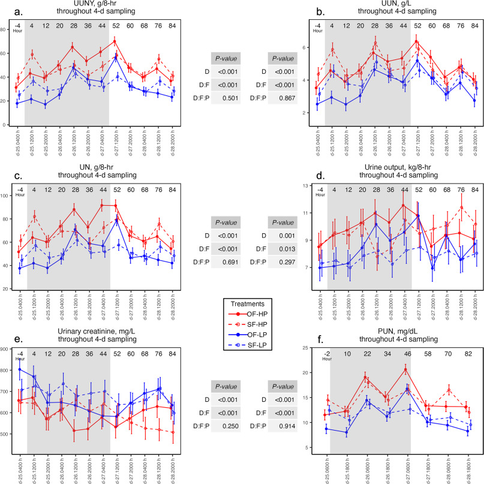

Figure 1. Temporal patterns in variables with significant feeding pattern by day interactions: a) Urinary urea-N yield (UUNY, g/8-h), b) urinary urea-N concentration (UUN, g/L), c) urinary N (g/8-h), d) urine output (kg/8-h), e) urine creatinine (mg/L), and f) plasma urea-N concentration (PUN, mg/dL). Results of F-tests for day (D) by feeding pattern (F) and crude protein level (P) are shown in tables. A gray rectangle shows the higher-CP phase in OF. Points show least squares means from linear mixed models with F, P, F:P, D, and sampling hour (H), with all possible interactions between temporal and treatment variables. Plots represent n = 360 (UUNY, UUN) and n = 240 (PUN) observations from n = 8 cows in the cannulated subset, across a 4-d sampling period under conditions of oscillating high protein (OF-HP, 15.5 ± 1.8% crude protein), and oscillating low protein (OF-LP, 13.8 ± 1.8% crude protein).

### Plasma AA concentrations

| CP Level CP Feeding Pattern | LP OF | LP SF | HP OF | HP SF | SEM | *P*-values CP Level | *P*-values CP Feeding Pattern | *P*-values CP Level * CP Feeding Pattern | *P*-values CP Feeding Pattern * Oscillation phase<sup>3</sup> |
| --- | --- | --- | --- | --- | --- | --- | --- | --- | --- |
| AA<sup>2</sup>, μM |  |  |  |  |  |  |  |  |  |
| Arg | 63.4 | 64.5 | 70.6 | 66.4 | 3.4 | 0.06 | 0.53 | 0.28 | 0.62 |
| His | 47.2 | 45.0 | 49.9 | 49.1 | 1.9 | 0.04 | 0.38 | 0.67 | 0.60 |
| Ile | 158.4 | 160.1 | 166.7 | 158.5 | 8.8 | 0.56 | 0.59 | 0.40 | 0.17 |
| Leu | 164.2 | 170.7 | 178.0 | 171.3 | 8.9 | 0.27 | 0.99 | 0.31 | 0.33 |
| Lys | 83.3 | 86.0 | 85.1 | 87.2 | 4.6 | 0.69 | 0.54 | 0.93 | 0.78 |
| Met | 15.1 | 14.9 | 16.8 | 16.1 | 0.8 | 0.03 | 0.48 | 0.67 | 0.42 |
| Phe | 52.1 | 49.9 | 62.6 | 52.3 | 4.4 | 0.11 | 0.12 | 0.31 | 0.05 |
| Thr | 93.9 | 93.4 | 94.2 | 92.8 | 5.1 | 0.94 | 0.74 | 0.87 | 0.49 |
| Trp | 52.6 | 49.7 | 50.8 | 50.8 | 2.5 | 0.80 | 0.32 | 0.30 | 0.31 |
| Val | 265.6 | 268.9 | 294.3 | 290.4 | 13.0 | <0.01 | 0.97 | 0.62 | 0.25 |
| Ala | 278.7 | 265.0 | 271.5 | 264.5 | 14.8 | 0.73 | 0.37 | 0.77 | 0.96 |
| Asn | 28.9 | 25.5 | 26.9 | 25.1 | 2.2 | 0.42 | 0.08 | 0.59 | 0.97 |
| Asp | 13.3 | 11.1 | 14.9 | 13.3 | 2.0 | 0.30 | 0.30 | 0.86 | 0.28 |
| Gln | 180.3 | 171.2 | 191.1 | 178.9 | 8.5 | 0.22 | 0.17 | 0.84 | 0.61 |
| Glu | 110.1 | 105.9 | 111.5 | 107.3 | 4.3 | 0.60 | 0.15 | 0.99 | 0.58 |
| Gly | 374.7 | 344.8 | 284.2 | 297.7 | 23.5 | <0.01 | 0.63 | 0.19 | 0.25 |
| Pro | 92.7 | 88.7 | 95.1 | 87.4 | 4.7 | 0.82 | 0.02 | 0.44 | 0.87 |
| Ser | 101.0 | 101.1 | 105.3 | 93.9 | 5.5 | 0.76 | 0.24 | 0.22 | 0.70 |
| Tyr | 52.5 | 53.0 | 58.7 | 55.3 | 3.0 | 0.08 | 0.55 | 0.41 | 0.07 |
| TAA | 2227 | 2175 | 2230 | 2164 | 61 | 0.93 | 0.20 | 0.87 | 0.16 |
| EAA | 995 | 1006 | 1069 | 1037 | 40 | 0.04 | 0.69 | 0.40 | 0.18 |
| NEAA | 1230 | 1170 | 1159 | 1127 | 37 | 0.07 | 0.15 | 0.65 | 0.38 |
| BCAA | 588 | 600 | 639 | 620 | 29 | 0.05 | 0.87 | 0.40 | 0.21 |

**1**

Data collected during the last 4-d of each 28-d sampling period.

**2**

TAA = total AA concentration (μM); EAA = essential AA (μM); NEAA = non-essential AA (μM); BCAA = branched chain AA (μM).

**3**

The CP feeding pattern by oscillation phase interaction shows whether the effects of 48-h phase on the analyte differed for static CP feeding versus oscillating CP feeding. A significant interaction indicates a different temporal pattern of response with OF versus SF across two 48 h phases in d 25 to d 28 of an experimental period.

### Gas Emissions

Table 5 shows gas production, intensity, and yield for the non-cannulated subset of cows in our trial. Results suggested minimal differences in gas emissions related to CP level and CP feeding pattern. Emissions of CH<sub>4</sub> and CO<sub>2</sub> in our trial were comparable to recent reports with similar dietary and cow conditions (Lage et al., 2021). Our results are consistent with Müller et al. (2021) which reported no differences in production of CH<sub>4</sub> and CO<sub>2</sub> and oxygen consumption when lowering protein and increasing starch (13.8% CP) relative to a higher-CP diet (15.9% CP), and Niu et al., 2016, Nutrient Requirements of Dairy Cattle: Eighth Revised Edition, 2021 which found no differences in enteric CH<sub>4</sub> production, intensity, or yield when comparing 15.2 and 18.5% dietary CP in a crossover study. In contrast, Gidlund et al. (2015) reported reduced CH<sub>4</sub> yield at moderate dietary CP (18.4–19.1%) compared with higher and lower dietary CP extremes (17.0–17.3% and 20.1–21.0%) where dietary NDF and pdNDF were similar across conditions. Importantly, dietary NDF and pdNDF changed modestly between LP and HP diets in our trial. The absence of CP level and CP feeding pattern effects suggests that conditions for methanogenesis (e.g., substrate availability, microbial community structure and fermentation activity) were similar among conditions.

Table 5. Gas emissions, oxygen consumption, and respiratory quotient cows fed diets varying in crude protein (CP): low protein (LP = 13.8% CP) or high protein (HP = 15.5% CP), with oscillating (OF, ± 1.8% CP at 48-h intervals) or static (SF) feeding patterns (Least squares means; n = 8 non-cannulated cows)<sup>1</sup>

| CP Level CP Feeding Pattern | LP OF | LP SF | HP OF | HP SF | SEM | *P*-values CP level | *P*-values CP feeding pattern | *P*-values Interaction |
| --- | --- | --- | --- | --- | --- | --- | --- | --- |
| DMI, kg/d | 26.4 | 26.8 | 26.4 | 25.9 | 1.0 | 0.40 | 0.94 | 0.44 |
| Milk, kg/d | 37.0 | 36.7 | 37.2 | 35.9 | 1.5 | 0.73 | 0.35 | 0.60 |
| FPCM<sup>2</sup>, kg/d | 37.5 | 36.3 | 37.2 | 36.2 | 1.6 | 0.82 | 0.27 | 0.93 |
| BW | 657 | 660 | 669 | 662 | 21 | 0.46 | 0.85 | 0.59 |
| BCS | 3.14 | 3.14 | 3.19 | 3.16 | 0.11 | 0.49 | 0.79 | 0.71 |
| CH<sub>4</sub> |  |  |  |  |  |  |  |  |
| Production, g/d | 473 | 473 | 483 | 466 | 26 | 0.89 | 0.48 | 0.46 |
| Intensity, g/kg FPCM | 12.7 | 13.0 | 13.2 | 13.0 | 0.7 | 0.59 | 0.92 | 0.54 |
| Yield, g/kg DMI | 17.9 | 17.5 | 18.5 | 18.1 | 0.8 | 0.28 | 0.49 | 0.92 |
| CO<sub>2</sub> |  |  |  |  |  |  |  |  |
| Production, g/d | 14,830 | 14,870 | 15,600 | 14,890 | 410 | 0.07 | 0.12 | 0.08 |
| Intensity, g/kg FPCM | 402 | 417 | 427 | 419 | 19 | 0.23 | 0.73 | 0.33 |
| Yield, g/kg DMI | 564 | 557 | 595 | 586 | 16 | 0.02 | 0.47 | 0.93 |
| CH<sub>4</sub>/CO<sub>2</sub>, L/L | 0.964 | 0.950 | 0.931 | 0.943 | 0.004 | 0.31 | 0.95 | 0.50 |
| Oxygen consumption, g/d | 10,200 | 10,220 | 10,600 | 10,420 | 332 | 0.10 | 0.65 | 0.57 |
| Respiratory quotient<sup>3</sup> | 1.05 | 1.05 | 1.07 | 1.03 | 0.02 | 0.87 | 0.27 | 0.26 |

**1**

Data collected during the last 4-d of each 28-d sampling period.

**2**

FPCM = fat-protein-corrected milk calculated per IDF (2022) as [(1.226 × milk fat concentration (g/100 g)) + (0.0776 × milk true protein concentration (g/100 g)) + 0.2534)].

**3**

Respiratory quotient = CO<sub>2</sub> (L/d) of CO<sub>2</sub> emitted divided by O<sub>2</sub> consumed (L/d).

Interestingly, we found that HP diets, especially OF-HP, tended to promote greater CO<sub>2</sub> production. In ruminants, enteric CH<sub>4</sub> production is largely determined by rumen fermentation capacity and fermentation patterns, whereas CO<sub>2</sub> arises predominantly from respiration and to a lesser extent from fermentation (Madsen et al., 2010). It is unclear whether CO<sub>2</sub> differences were caused at the rumen-level (e.g., alterations to microbial biomass, species composition, or substrate usage), or at the whole-animal level (e.g., changes in macronutrient metabolism, body composition, and maintenance requirements). In a Ussing chamber experiment with ruminal epithelia from growing lambs fed oscillating and static CP diets, Doranelli et al. (2011) found greater urea flux from tissues collected after the lower CP oscillation phase relative to the higher CP phase. Although these authors showed no differences in urea flux between oscillating and static dietary CP treatments, it is possible that differences in urea flux and microbial ureolytic activity could affect intraruminal CO<sub>2</sub> production (Doranelli et al., 2011). At the whole-animal level, Liu et al. (1995) observed that some growing lambs exhibited marked declines in protein synthesis and degradation at 2 d after switching from maintenance to low protein intragastric infusions. Talal et al. (2020) suggested that greater CO<sub>2</sub> yield could occur with lipogenesis or upregulation of the pentose phosphate pathway. Tissue protein turnover could consume oxygen and produce CO<sub>2</sub> without affecting CH<sub>4</sub> production (Hanigan et al., 2009). Additionally, CO<sub>2</sub> emissions could be affected by bicarbonate usage in body buffering systems which HP diets may have affected by increasing urea transport into the rumen and into urine (Laporte-Uribe, 2019; Tebbe and Weiss, 2020). Tracking fermentative and respiratory emissions may increase in importance with carbon measurement and accounting schemes.

## CONCLUSION

Our trial tested the effects of CP level, CP feeding pattern, and their interaction on N balance, nutrient digestibility, and gas emissions with mid- to late-lactation Holstein cows. Contrary to our hypothesis, CP feeding pattern had minimal effects on measured variables, regardless of the average CP level (LP = 13.8 vs. HP = 15.5% of DM). Crude protein level did not alter milk N. Instead, feeding the HP diets led to effects consistent with N overfeeding, such as increased UUNY, UUN, and UCR, and reduced NUE. Time series analysis of UUNY, UUN, and PUN showed that these body and excreta urea-N pools responded to increased and decreased dietary CP within 48-h intervals (2 feedings) and that responses to dietary N were consistent with previous meta-analytical research. Interestingly, the HP diets increased urinary creatinine excretion, increased plasma EAA concentrations, and tended to decrease plasma NEAA concentrations, which could suggest differences in macronutrient metabolism. Production of CO<sub>2</sub> was also greater for cows fed the OF-HP diet compared with the other dietary treatments. In summary, the 48-h dietary CP oscillations in our trial had minimal effects on N balance, nutrient digestibility, and gas fluxes at CP levels near (HP) or below (LP) predicted MP requirements.

## ACKNOWLEDGMENTS

This study was funded by Hatch Grants WIS04003 and WIS05009. This research was also supported by funding from the USDA, Agricultural Research Service under National Program 101 Food Animal Production Current Research Information System (CRIS) funds (project nos. 5090-31000-026-00D and 5090-31000-028-00D). This research was supported in part by an appointment of Levi Svaren to the Agricultural Research Service (ARS) Research Participation Program administered by the Oak Ridge Institute for Science and Education (ORISE) through an interagency agreement between the U.S. Department of Energy (DOE) and the U.S. Department of Agriculture (USDA). ORISE is managed by ORAU under DOE contract number DE-SC0014664. All opinions expressed in this paper are the authors' and do not necessarily reflect the policies and views of USDA, DOE, or ORAU/ORISE. Mention of any trademark or proprietary product in this manuscript does not constitute a guarantee or warranty of the product by the USDA or the Agricultural Research Service and does not imply its approval to the exclusion of other products that also may be suitable. USDA is an equal opportunity provider and employer. The authors have no known conflicts of interest. We acknowledge Wendy Radloff and Mary Becker (US Dairy Forage Research Center, Madison, WI) for conducting chemical analysis of feeds, feces, and urine. Finally, we thank the UW—Madison Dairy Cattle Center farm staff; and Paulina Letelier, Dante Pizarro, Kate Wells, Kaylee Riesgraf, Alyssa Seitz, Haden Hartwig, Siena Finlayson, Mary Geurts, and Sara Zentner (University of Wisconsin—Madison, Madison, WI) for their assistance with sampling and laboratory analysis.

## APPENDIX

Appendix Table 1. Target and predicted efficiencies of metabolizable AA use for cows (n = 16) fed diets varying in crude protein (CP): low protein (LP = 13.8% CP) or high protein (HP = 15.5% CP), with oscillating (OF, ± 1.8% CP at 48-h intervals) or static (SF) feeding patterns<sup>1</sup>

| AA | Target | OF-LP Low phase | OF-HP Low phase; SF-LP | OF-LP High phase; SF-HP | OF-HP High phase |
| --- | --- | --- | --- | --- | --- |
| Arg |  | 0.59 | 0.51 | 0.44 | 0.40 |
| His | 0.75 | 1.00 | 0.87 | 0.78 | 0.70 |
| Ile | 0.71 | 0.77 | 0.68 | 0.61 | 0.55 |
| Leu | 0.73 | 0.88 | 0.79 | 0.71 | 0.65 |
| Lys | 0.72 | 0.87 | 0.76 | 0.68 | 0.61 |
| Met | 0.73 | 1.01 | 0.90 | 0.81 | 0.74 |
| Phe | 0.60 | 0.71 | 0.62 | 0.56 | 0.51 |
| Thr | 0.64 | 0.76 | 0.67 | 0.60 | 0.55 |
| Trp | 0.86 | 0.98 | 0.86 | 0.76 | 0.68 |
| Val | 0.74 | 0.87 | 0.77 | 0.69 | 0.63 |

**1**

Based on NASEM (2021) using measured DMI, milk yield and composition, BW, DIM, and days in gestation for the trial averaged across all cows.

## REFERENCES

1. Aguerre et al., 2016

   M.J. Aguerre, M.C. Capozzolo, P. Lencioni, C. Cabral, M.A. Wattiaux

   Effect of quebracho-chestnut tannin extracts at 2 dietary crude protein levels on performance, rumen fermentation, and nitrogen partitioning in dairy cows

   J. Dairy Sci., 99 (2016), pp. 4476-4486

   https://doi.org/10.3168/jds.2015-10745

   27060814

   [View PDF](https://www.sciencedirect.com/science/article/pii/S0022030216301515/pdfft?md5=0882d37a12351f5234b1b21d4f3e0c95&pid=1-s2.0-S0022030216301515-main.pdf)[View article](https://www.sciencedirect.com/science/article/pii/S0022030216301515)[CrossRef](https://doi.org/10.3168/jds.2015-10745)[View in Scopus](https://www.scopus.com/inward/record.url?eid=2-s2.0-84962690944&partnerID=10&rel=R3.0.0)Google Scholar
2. AOAC International, 1996

   AOAC International

   Official Methods of Analysis

   (16th ed.), Association of Official Analytical Chemists, Washington, D.C. (1996)

   [Google Scholar](https://scholar.google.com/scholar_lookup?title=Official%20Methods%20of%20Analysis&publication_year=1996&author=AOAC%20International)
3. Barros et al., 2017

   T. Barros, M.A. Quaassdorff, M.J. Aguerre, J.J.O. Colmenero, S.J. Bertics, P.M. Crump, M.A. Wattiaux

   Effects of dietary crude protein concentration on late-lactation dairy cow performance and indicators of nitrogen utilization

   J. Dairy Sci., 100 (2017), pp. 5434-5448

   https://doi.org/10.3168/jds.2016-11917

   28501404

   [View PDF](https://www.sciencedirect.com/science/article/pii/S0022030217304083/pdfft?md5=b2c46c0d19a4de68e8d78626c7e120e4&pid=1-s2.0-S0022030217304083-main.pdf)[View article](https://www.sciencedirect.com/science/article/pii/S0022030217304083)[CrossRef](https://doi.org/10.3168/jds.2016-11917)[View in Scopus](https://www.scopus.com/inward/record.url?eid=2-s2.0-85019156518&partnerID=10&rel=R3.0.0)Google Scholar
4. Barros et al., 2019

   T. Barros, K.F. Reed, J.J. Olmos Colmenero, M.A. Wattiaux

   Short communication: Milk urea nitrogen as a predictor of urinary nitrogen and urea nitrogen excretions of late-lactation dairy cows fed nitrogen-limiting diets

   J. Dairy Sci., 102 (2019), pp. 1601-1607

   https://doi.org/10.3168/jds.2018-14551

   30471912

   [View PDF](https://www.sciencedirect.com/science/article/pii/S0022030218310749/pdfft?md5=7efaa286435fde3866072350cd6ca14a&pid=1-s2.0-S0022030218310749-main.pdf)[View article](https://www.sciencedirect.com/science/article/pii/S0022030218310749)[CrossRef](https://doi.org/10.3168/jds.2018-14551)[View in Scopus](https://www.scopus.com/inward/record.url?eid=2-s2.0-85060293996&partnerID=10&rel=R3.0.0)Google Scholar
5. Bates et al., 2015

   D. Bates, M. Mächler, B. Bolker, S. Walker

   Fitting linear mixed-effects models using lme4

   J. Stat. Softw., 67 (2015)

   https://doi.org/10.18637/jss.v067.i01

   [Google Scholar](https://scholar.google.com/scholar_lookup?title=Fitting%20linear%20mixed-effects%20models%20using%20lme4&publication_year=2015&author=D.%20Bates&author=M.%20M%C3%A4chler&author=B.%20Bolker&author=S.%20Walker)
6. Belanche et al., 2012

   A. Belanche, M. Doreau, J.E. Edwards, J.M. Moorby, E. Pinloche, C.J. Newbold

   Shifts in the rumen microbiota due to the type of carbohydrate and level of protein ingested by dairy cattle are associated with changes in rumen fermentation

   J. Nutr., 142 (2012), pp. 1684-1692

   https://doi.org/10.3945/jn.112.159574

   22833657

   [View PDF](https://www.sciencedirect.com/science/article/pii/S0022316622026815/pdfft?md5=2ead7fa774eb01f9e13ea6e85625b12c&pid=1-s2.0-S0022316622026815-main.pdf)[View article](https://www.sciencedirect.com/science/article/pii/S0022316622026815)[CrossRef](https://doi.org/10.3945/jn.112.159574)[View in Scopus](https://www.scopus.com/inward/record.url?eid=2-s2.0-84866302168&partnerID=10&rel=R3.0.0)Google Scholar
7. Benchaar et al., 2023

   C. Benchaar, F. Hassanat, K.A. Beauchemin, D.R. Ouellet, H. Lapierre, C. Côrtes

   Effect of metabolizable protein supply on milk performance, ruminal fermentation, apparent total-tract digestibility, energy and nitrogen utilization, and enteric methane production of Ayrshire and Holstein Cows

   Animals (Basel), 13 (2023), p. 832

   https://doi.org/10.3390/ani13050832

   36899689

   [CrossRef](https://doi.org/10.3390/ani13050832)[View in Scopus](https://www.scopus.com/inward/record.url?eid=2-s2.0-85149774993&partnerID=10&rel=R3.0.0)Google Scholar
8. Brito and Broderick, 2006

   A.F. Brito, G.A. Broderick

   Effect of varying dietary ratios of alfalfa silage to corn silage on production and nitrogen utilization in lactating dairy cows

   J. Dairy Sci., 89 (2006), pp. 3924-3938

   https://doi.org/10.3168/jds.S0022-0302(06)72435-3

   16960068

   [View PDF](https://www.sciencedirect.com/science/article/pii/S0022030206724353/pdfft?md5=1be7e1daae9b8ba91e7cc2ba1d9fa7d9&pid=1-s2.0-S0022030206724353-main.pdf)[View article](https://www.sciencedirect.com/science/article/pii/S0022030206724353)[View in Scopus](https://www.scopus.com/inward/record.url?eid=2-s2.0-33749421463&partnerID=10&rel=R3.0.0)Google Scholar
9. Broderick, 2003

   G.A. Broderick

   Effects of varying dietary protein and energy levels on the production of lactating dairy cows

   J. Dairy Sci., 86 (2003), pp. 1370-1381

   https://doi.org/10.3168/jds.S0022-0302(03)73721-7

   12741562

   [View PDF](https://www.sciencedirect.com/science/article/pii/S0022030203737217/pdfft?md5=095627ba7698a4405a0033a8e05fc038&pid=1-s2.0-S0022030203737217-main.pdf)[View article](https://www.sciencedirect.com/science/article/pii/S0022030203737217)[View in Scopus](https://www.scopus.com/inward/record.url?eid=2-s2.0-0038749352&partnerID=10&rel=R3.0.0)Google Scholar
10. Broderick et al., 2009

    G.A. Broderick, M.J. Stevenson, R.A. Patton

    Effect of dietary protein concentration and degradability on response to rumen-protected methionine in lactating dairy cows

    J. Dairy Sci., 92 (2009), pp. 2719-2728

    https://doi.org/10.3168/jds.2008-1277

    19448006

    [View PDF](https://www.sciencedirect.com/science/article/pii/S0022030209705892/pdfft?md5=c6cdc9672e95cdf7db75363a74a774c9&pid=1-s2.0-S0022030209705892-main.pdf)[View article](https://www.sciencedirect.com/science/article/pii/S0022030209705892)[CrossRef](https://doi.org/10.3168/jds.2008-1277)[View in Scopus](https://www.scopus.com/inward/record.url?eid=2-s2.0-61449169002&partnerID=10&rel=R3.0.0)Google Scholar
11. Brown, 2014

    A.N. Brown

    Effects of oscillating crude protein content of dairy cow diets

    The Ohio State University (2014)

    [Google Scholar](https://scholar.google.com/scholar_lookup?title=Effects%20of%20oscillating%20crude%20protein%20content%20of%20dairy%20cow%20diets&publication_year=2014&author=A.N.%20Brown)
12. Chen et al., 2022

    Y. Chen, H. Atashi, C. Grelet, S. Vanderick, H. Hu, N. Gengler

    Defining a nitrogen efficiency index in Holstein cows and assessing its potential effect on the breeding program of bulls

    J. Dairy Sci., 105 (2022), pp. 7575-7587

    https://doi.org/10.3168/jds.2021-21681

    35931481

    [View PDF](https://www.sciencedirect.com/science/article/pii/S0022030222004350/pdfft?md5=8a415c278ad2a1941d1e011983432024&pid=1-s2.0-S0022030222004350-main.pdf)[View article](https://www.sciencedirect.com/science/article/pii/S0022030222004350)[CrossRef](https://doi.org/10.3168/jds.2021-21681)[View in Scopus](https://www.scopus.com/inward/record.url?eid=2-s2.0-85135342615&partnerID=10&rel=R3.0.0)Google Scholar
13. De Souza et al., 2018

    R. De Souza, R. Tempelman, M. Allen, W. Weiss, J. Bernard, M. VandeHaar

    Predicting nutrient digestibility in high-producing dairy cows

    J. Dairy Sci., 101 (2018), pp. 1123-1135

    https://doi.org/10.3168/jds.2017-13344

    29174147

    [View PDF](https://www.sciencedirect.com/science/article/pii/S0022030217310950/pdfft?md5=5887b7eab2dc03b8a1ec07e09ec3da88&pid=1-s2.0-S0022030217310950-main.pdf)[View article](https://www.sciencedirect.com/science/article/pii/S0022030217310950)[CrossRef](https://doi.org/10.3168/jds.2017-13344)[View in Scopus](https://www.scopus.com/inward/record.url?eid=2-s2.0-85035000236&partnerID=10&rel=R3.0.0)Google Scholar
14. Dijkstra et al., 2013

    J. Dijkstra, C.K. Reynolds, E. Kebreab, A. Bannink, J.L. Ellis, J. France, A.M. van Vuuren

    Challenges in ruminant nutrition: towards minimal nitrogen losses in cattle

    Energy Protein Metab. Nutr. Sustain. Anim. Prod. (2013), pp. 47-58

    https://doi.org/10.3920/978-90-8686-781-3_3

    [CrossRef](https://doi.org/10.3920/978-90-8686-781-3_3)Google Scholar
15. Doranalli et al., 2011

    K. Doranalli, G.B. Penner, T. Mutsvangwa

    Feeding oscillating dietary crude protein concentrations increases nitrogen utilization in growing lambs and this response is partly attributable to increased urea transfer to the rumen

    J. Nutr., 141 (2011), pp. 560-567

    https://doi.org/10.3945/jn.110.133876

    21310865

    [View PDF](https://www.sciencedirect.com/science/article/pii/S0022316622025524/pdfft?md5=fbc639269fa1d5a82452ddab0cc69871&pid=1-s2.0-S0022316622025524-main.pdf)[View article](https://www.sciencedirect.com/science/article/pii/S0022316622025524)[CrossRef](https://doi.org/10.3945/jn.110.133876)[View in Scopus](https://www.scopus.com/inward/record.url?eid=2-s2.0-79955505072&partnerID=10&rel=R3.0.0)Google Scholar
16. Erickson et al., 2023

    M.G. Erickson, G.I. Zanton, M.A. Wattiaux

    Dynamic lactation responses to dietary crude protein oscillation in diets adequate and deficient in metabolizable protein in Holstein cows

    J. Dairy Sci. (2023)

    https://doi.org/10.3168/jds.2023-23603

    37678780

    Google Scholar
17. Gidlund et al., 2015

    H. Gidlund, M. Hetta, S.J. Krizsan, S. Lemosquet, P. Huhtanen

    Effects of soybean meal or canola meal on milk production and methane emissions in lactating dairy cows fed grass silage-based diets

    J. Dairy Sci., 98 (2015), pp. 8093-8106

    https://doi.org/10.3168/jds.2015-9757

    26364100

    [View PDF](https://www.sciencedirect.com/science/article/pii/S0022030215006578/pdfft?md5=4e66d64bda22807d6569328ed2d4a781&pid=1-s2.0-S0022030215006578-main.pdf)[View article](https://www.sciencedirect.com/science/article/pii/S0022030215006578)[CrossRef](https://doi.org/10.3168/jds.2015-9757)[View in Scopus](https://www.scopus.com/inward/record.url?eid=2-s2.0-84944167681&partnerID=10&rel=R3.0.0)Google Scholar
18. Hanigan et al., 2009

    M.D. Hanigan, J. France, S.J. Mabjeesh, W.C. McNabb, B.J. Bequette

    High rates of mammary tissue protein turnover in lactating goats are energetically costly

    J. Nutr., 139 (2009), pp. 1118-1127

    https://doi.org/10.3945/jn.108.103002

    19403714

    [View PDF](https://www.sciencedirect.com/science/article/pii/S002231662206549X/pdfft?md5=6c1bbc6c762bffc58acab07e6bc528c3&pid=1-s2.0-S002231662206549X-main.pdf)[View article](https://www.sciencedirect.com/science/article/pii/S002231662206549X)[CrossRef](https://doi.org/10.3945/jn.108.103002)[View in Scopus](https://www.scopus.com/inward/record.url?eid=2-s2.0-66749166439&partnerID=10&rel=R3.0.0)Google Scholar
19. Haque et al., 2013

    M.N. Haque, H. Rulquin, S. Lemosquet

    Milk protein responses in dairy cows to changes in postruminal supplies of arginine, isoleucine, and valine

    J. Dairy Sci., 96 (2013), pp. 420-430

    https://doi.org/10.3168/jds.2012-5610

    23164225

    [View PDF](https://www.sciencedirect.com/science/article/pii/S0022030212008417/pdfft?md5=786e838a47e8ca448ae827c5b916a772&pid=1-s2.0-S0022030212008417-main.pdf)[View article](https://www.sciencedirect.com/science/article/pii/S0022030212008417)[CrossRef](https://doi.org/10.3168/jds.2012-5610)[View in Scopus](https://www.scopus.com/inward/record.url?eid=2-s2.0-84871618583&partnerID=10&rel=R3.0.0)Google Scholar
20. Hynes et al., 2016

    D.N. Hynes, S. Stergiadis, A. Gordon, T. Yan

    Effects of concentrate crude protein content on nutrient digestibility, energy utilization, and methane emissions in lactating dairy cows fed fresh-cut perennial grass

    J. Dairy Sci., 99 (2016), pp. 8858-8866

    https://doi.org/10.3168/jds.2016-11509

    27592423

    [View PDF](https://www.sciencedirect.com/science/article/pii/S0022030216305975/pdfft?md5=f92904279b7d8429b334e193cda8116f&pid=1-s2.0-S0022030216305975-main.pdf)[View article](https://www.sciencedirect.com/science/article/pii/S0022030216305975)[CrossRef](https://doi.org/10.3168/jds.2016-11509)[View in Scopus](https://www.scopus.com/inward/record.url?eid=2-s2.0-84994085897&partnerID=10&rel=R3.0.0)Google Scholar
21. International Dairy Federation (IDF), 2022

    International Dairy Federation (IDF). 2022. The IDF global Carbon Footprint standard for the dairy sector.

    Google Scholar
22. Kohler, 2016

    J. Kohler

    The influence of oscillating dietary crude protein concentrations on milk production and nitrogen utilization in lactating dairy cows

    Master’s thesis.

    Agricultural and Bioresource Engineering, University of Saskatchewan, Saskatoon, SK, Canada (2016)

    https://harvest.usask.ca/handle/10388/7292?show=full

    Google Scholar
23. Kuznetsova et al., 2017

    A. Kuznetsova, P.B. Brockhoff, R.H.B. Christensen

    lmerTest Package: Tests in Linear Mixed Effects Models

    J. Stat. Softw., 82 (2017)

    https://doi.org/10.18637/jss.v082.i13

    Google Scholar
24. Lage et al., 2021

    C.F.A. Lage, S.E. Räisänen, H. Stefenoni, A. Melgar, X. Chen, J. Oh, M.E. Fetter, D.M. Kniffen, R.A. Fabin, A.N. Hristov

    Lactational performance, enteric gas emissions, and plasma amino acid profile of dairy cows fed diets with soybean or canola meals included on an equal protein basis

    J. Dairy Sci., 104 (2021), pp. 3052-3066

    https://doi.org/10.3168/jds.2020-18851

    33455785

    [View PDF](https://www.sciencedirect.com/science/article/pii/S0022030221000138/pdfft?md5=181dd496516ea49f8deff82dbae35945&pid=1-s2.0-S0022030221000138-main.pdf)[View article](https://www.sciencedirect.com/science/article/pii/S0022030221000138)[CrossRef](https://doi.org/10.3168/jds.2020-18851)[View in Scopus](https://www.scopus.com/inward/record.url?eid=2-s2.0-85099447427&partnerID=10&rel=R3.0.0)Google Scholar
25. Lapierre et al., 2007

    H. Lapierre, G. Lobley, D. Ouellet, L. Doepel, D. Pacheco

    Amino acid requirements for lactating dairy cows: Reconciling predictive models and biology

    Proc. Cornell Nutr. Conf, Dept. Anim. Sci., Cornell Univ., Ithaca, NY (2007), pp. 39-60

    Google Scholar
26. Lapierre and Lobley, 2001

    H. Lapierre, G.E. Lobley

    Nitrogen recycling in the ruminant: A review

    J. Dairy Sci., 84 (2001), pp. E223-E236

    https://doi.org/10.3168/jds.S0022-0302(01)70222-6

    [View PDF](https://www.sciencedirect.com/science/article/pii/S0022030201702226/pdf?md5=d2f242e6e916e8e2355bbe2128aa8d09&pid=1-s2.0-S0022030201702226-main.pdf)[View article](https://www.sciencedirect.com/science/article/pii/S0022030201702226)[Google Scholar](https://scholar.google.com/scholar_lookup?title=Nitrogen%20recycling%20in%20the%20ruminant%3A%20A%20review&publication_year=2001&author=H.%20Lapierre&author=G.E.%20Lobley)
27. Lapierre et al., 2020

    H. Lapierre, R. Martineau, M.D. Hanigan, H.J. van Lingen, E. Kebreab, J.W. Spek, D.R. Ouellet

    Review: Impact of protein and energy supply on the fate of amino acids from absorption to milk protein in dairy cows

    Animal, 14 (2020), pp. s87-s102

    https://doi.org/10.1017/S1751731119003173

    32024565

    [View PDF](https://www.sciencedirect.com/science/article/pii/S1751731119003173/pdfft?md5=b9ee3a09c6376771c5332393875f21a3&pid=1-s2.0-S1751731119003173-main.pdf)[View article](https://www.sciencedirect.com/science/article/pii/S1751731119003173)[CrossRef](https://doi.org/10.1017/s1751731119003173)Google Scholar
28. Laporte-Uribe, 2019

    J.A. Laporte-Uribe

    Rumen CO2 species equilibrium might influence performance and be a factor in the pathogenesis of subacute ruminal acidosis

    Transl. Anim. Sci., 3 (2019), pp. 1081-1098

    https://doi.org/10.1093/tas/txz144

    32704872

    [CrossRef](https://doi.org/10.1093/tas/txz144)[View in Scopus](https://www.scopus.com/inward/record.url?eid=2-s2.0-85084563200&partnerID=10&rel=R3.0.0)Google Scholar
29. Lee et al., 2019

    C. Lee, D.L. Morris, P.A. Dieter

    Validating and optimizing spot sampling of urine to estimate urine output with creatinine as a marker in dairy cows

    J. Dairy Sci., 102 (2019), pp. 236-245

    https://doi.org/10.3168/jds.2018-15121

    30391180

    [View PDF](https://www.sciencedirect.com/science/article/pii/S002203021831018X/pdfft?md5=4f7f3fc3146aa89d1c6e1915cfd3f1aa&pid=1-s2.0-S002203021831018X-main.pdf)[View article](https://www.sciencedirect.com/science/article/pii/S002203021831018X)[CrossRef](https://doi.org/10.3168/jds.2018-15121)[View in Scopus](https://www.scopus.com/inward/record.url?eid=2-s2.0-85055741799&partnerID=10&rel=R3.0.0)Google Scholar
30. Lenth, 2016

    R.V. Lenth

    Least-Squares Means: TheRPackagelsmeans

    J. Stat. Softw., 69 (2016)

    https://doi.org/10.18637/jss.v069.i01

    [Google Scholar](https://scholar.google.com/scholar_lookup?title=Least-Squares%20Means%3A%20TheRPackagelsmeans&publication_year=2016&author=R.V.%20Lenth)
31. Letelier et al., 2022

    P. Letelier, G.I. Zanton, M.A. Wattiaux

    Production performance of Holstein cows at 4 stages of lactation fed 4 dietary crude protein concentrations

    J. Dairy Sci., 105 (2022), pp. 9581-9596

    https://doi.org/10.3168/jds.2022-22146

    36307237

    [View PDF](https://www.sciencedirect.com/science/article/pii/S0022030222006166/pdfft?md5=5ffdd663d13faabde4cff42c5edef642&pid=1-s2.0-S0022030222006166-main.pdf)[View article](https://www.sciencedirect.com/science/article/pii/S0022030222006166)[CrossRef](https://doi.org/10.3168/jds.2022-22146)[View in Scopus](https://www.scopus.com/inward/record.url?eid=2-s2.0-85140406591&partnerID=10&rel=R3.0.0)Google Scholar
32. Little and Rubin, 2002

    R.J.A. Little, D.B. Rubin

    Statistical Analysis with Missing Data

    John Wiley & Sons, Inc., Hoboken, NJ (2002)

    https://doi.org/10.1002/9781119013563

    [Google Scholar](https://scholar.google.com/scholar_lookup?title=Statistical%20Analysis%20with%20Missing%20Data&publication_year=2002&author=R.J.A.%20Little&author=D.B.%20Rubin)
33. Liu et al., 2021

    E. Liu, M.D. Hanigan, M.J. VandeHaar

    Importance of considering body weight change in response to dietary protein deficiency in lactating dairy cows

    J. Dairy Sci., 104 (2021), pp. 11567-11579

    https://doi.org/10.3168/jds.2020-19566

    34419275

    [View PDF](https://www.sciencedirect.com/science/article/pii/S002203022100802X/pdfft?md5=b9080a2099eb3423d143c5ecd92b31c0&pid=1-s2.0-S002203022100802X-main.pdf)[View article](https://www.sciencedirect.com/science/article/pii/S002203022100802X)[CrossRef](https://doi.org/10.3168/jds.2020-19566)[View in Scopus](https://www.scopus.com/inward/record.url?eid=2-s2.0-85113772358&partnerID=10&rel=R3.0.0)Google Scholar
34. Liu et al., 1995

    S.M. Liu, G.E. Lobley, N.A. Macleod, D.J. Kyle, X.B. Chen, E.R. Ørskov

    Effects of long-term protein excess or deficiency on whole-body protein turnover in sheep nourished by intragastric infusion of nutrients

    Br. J. Nutr., 73 (1995), pp. 829-839

    https://doi.org/10.1079/BJN19950088

    7632664

    [View in Scopus](https://www.scopus.com/inward/record.url?eid=2-s2.0-0029053443&partnerID=10&rel=R3.0.0)Google Scholar
35. Lobley and Lapierre, 2003

    G. Lobley, H. Lapierre, *et al.*

    Post-absorptive metabolism of amino acids

    Publ.-. Eur. Assoc. Anim. Prod., 109 (2003), pp. 737-756

    [Google Scholar](https://scholar.google.com/scholar_lookup?title=Post-absorptive%20metabolism%20of%20amino%20acids&publication_year=2003&author=G.%20Lobley&author=H.%20Lapierre)
36. Ludden et al., 2003

    P.A. Ludden, T.L. Wechter, E.J. Scholljegerdes, B.W. Hess

    Effects of oscillating dietary protein on growth, efficiency, and serum metabolites in growing beef steers

    Prof. Anim. Sci., 19 (2003), pp. 30-34

    https://doi.org/10.15232/S1080-7446(15)31371-1

    [View PDF](https://www.sciencedirect.com/science/article/pii/S1080744615313711/pdf?md5=21c0a6593fbf1d601eca0da67fd99d9f&pid=1-s2.0-S1080744615313711-main.pdf)[View article](https://www.sciencedirect.com/science/article/pii/S1080744615313711)[View in Scopus](https://www.scopus.com/inward/record.url?eid=2-s2.0-85007552080&partnerID=10&rel=R3.0.0)Google Scholar
37. Madsen et al., 2010

    J. Madsen, B.S. Bjerg, T. Hvelplund, M.R. Weisbjerg, P. Lund

    Methane and carbon dioxide ratio in excreted air for quantification of the methane production from ruminants

    Livest. Sci., 129 (2010), pp. 223-227

    https://doi.org/10.1016/j.livsci.2010.01.001

    [View PDF](https://www.sciencedirect.com/science/article/pii/S1871141310000181/pdfft?md5=d55ab5cecc3b5494f3b9142ed9320f10&pid=1-s2.0-S1871141310000181-main.pdf)[View article](https://www.sciencedirect.com/science/article/pii/S1871141310000181)[View in Scopus](https://www.scopus.com/inward/record.url?eid=2-s2.0-77649271359&partnerID=10&rel=R3.0.0)Google Scholar
38. Martineau et al., 2019

    R. Martineau, D.R. Ouellet, R.A. Patton, R.R. White, H. Lapierre

    Plasma essential amino acid concentrations in response to casein infusion or ration change in dairy cows: A multilevel, mixed-effects meta-analysis

    J. Dairy Sci., 102 (2019), pp. 1312-1329

    https://doi.org/10.3168/jds.2018-15218

    30594385

    [View PDF](https://www.sciencedirect.com/science/article/pii/S0022030218311275/pdfft?md5=63c3dfe8e7803fcfb847e06c3a566dfd&pid=1-s2.0-S0022030218311275-main.pdf)[View article](https://www.sciencedirect.com/science/article/pii/S0022030218311275)[CrossRef](https://doi.org/10.3168/jds.2018-15218)[View in Scopus](https://www.scopus.com/inward/record.url?eid=2-s2.0-85058996686&partnerID=10&rel=R3.0.0)Google Scholar
39. Mertens, 2002

    D.R. Mertens

    Gravimetric Determination of Amylase-Treated Neutral Detergent Fiber in Feeds with Refluxing in Beakers or Crucibles: Collaborative Study

    J. AOAC Int., 85 (2002), pp. 1217-1240

    12477183

    [View in Scopus](https://www.scopus.com/inward/record.url?eid=2-s2.0-0040673824&partnerID=10&rel=R3.0.0)Google Scholar
40. Müller et al., 2021

    C.B.M. Müller, S. Görs, M. Derno, A. Tuchscherer, K. Wimmers, A. Zeyner, B. Kuhla

    Differences between Holstein dairy cows in renal clearance rate of urea affect milk urea concentration and the relationship between milk urea and urinary nitrogen excretion

    Sci. Total Environ., 755 (2021), Article 143198

    https://doi.org/10.1016/j.scitotenv.2020.143198

    33162136

    Google Scholar
41. Mutsvangwa et al., 2016

    T. Mutsvangwa, K.L. Davies, J.J. McKinnon, D.A. Christensen

    Effects of dietary crude protein and rumen-degradable protein concentrations on urea recycling, nitrogen balance, omasal nutrient flow, and milk production in dairy cows

    J. Dairy Sci., 99 (2016), pp. 6298-6310

    https://doi.org/10.3168/jds.2016-10917

    27236760

    [View PDF](https://www.sciencedirect.com/science/article/pii/S002203021630296X/pdfft?md5=5bd4ed52439b4198e225808b284e15e0&pid=1-s2.0-S002203021630296X-main.pdf)[View article](https://www.sciencedirect.com/science/article/pii/S002203021630296X)[CrossRef](https://doi.org/10.3168/jds.2016-10917)[View in Scopus](https://www.scopus.com/inward/record.url?eid=2-s2.0-84970005760&partnerID=10&rel=R3.0.0)Google Scholar
42. Nennich et al., 2006

    T.D. Nennich, J.H. Harrison, L.M. VanWieringen, N.R. St-Pierre, R.L. Kincaid, M.A. Wattiaux, D.L. Davidson, E. Block

    Prediction and evaluation of urine and urinary nitrogen and mineral excretion from dairy cattle

    J. Dairy Sci., 89 (2006), pp. 353-364

    https://doi.org/10.3168/jds.S0022-0302(06)72101-4

    16357300

    [View PDF](https://www.sciencedirect.com/science/article/pii/S0022030206721014/pdfft?md5=1a309dd766336c48bb2df6fadbcfc90b&pid=1-s2.0-S0022030206721014-main.pdf)[View article](https://www.sciencedirect.com/science/article/pii/S0022030206721014)[View in Scopus](https://www.scopus.com/inward/record.url?eid=2-s2.0-30844434305&partnerID=10&rel=R3.0.0)Google Scholar
43. Niu et al., 2016

    M. Niu, J.A.D.R.N. Appuhamy, A.B. Leytem, R.S. Dungan, E. Kebreab, M. Niu, J.A.D.R.N. Appuhamy, A.B. Leytem, R.S. Dungan, E. Kebreab

    Effect of dietary crude protein and forage contents on enteric methane emissions and nitrogen excretion from dairy cows simultaneously

    Anim. Prod. Sci., 56 (2016), pp. 312-321

    https://doi.org/10.1071/AN15498

    [View in Scopus](https://www.scopus.com/inward/record.url?eid=2-s2.0-84958159649&partnerID=10&rel=R3.0.0)Google Scholar
44. Nutrient Requirements of Dairy Cattle: Eighth Revised Edition, 2021

    Nutrient Requirements of Dairy Cattle: Eighth Revised Edition

    National Academies Press, Washington, D.C (2021)

    [Google Scholar](https://scholar.google.com/scholar?q=Nutrient%20Requirements%20of%20Dairy%20Cattle%3A%20Eighth%20Revised%20Edition.%202021.%20National%20Academies%20Press%2C%20Washington%2C%20D.C.%0A%09%09%09%09%09)
45. Olmos Colmenero and Broderick, 2006

    J.J. Olmos Colmenero, G.A. Broderick

    Effect of dietary crude protein concentration on milk production and nitrogen utilization in lactating dairy cows

    J. Dairy Sci., 89 (2006), pp. 1704-1712

    https://doi.org/10.3168/jds.S0022-0302(06)72238-X

    16606741

    [View in Scopus](https://www.scopus.com/inward/record.url?eid=2-s2.0-33745894650&partnerID=10&rel=R3.0.0)Google Scholar
46. Omphalius et al., 2019

    C. Omphalius, H. Lapierre, J. Guinard-Flament, P. Lamberton, L. Bahloul, S. Lemosquet

    Amino acid efficiencies of utilization vary by different mechanisms in response to energy and protein supplies in dairy cows: Study at mammary-gland and whole-body levels

    J. Dairy Sci., 102 (2019), pp. 9883-9901

    https://doi.org/10.3168/jds.2019-16433

    31477306

    [View PDF](https://www.sciencedirect.com/science/article/pii/S0022030219307465/pdfft?md5=3f635bc4e742fb6ca1e2b32f97e015b7&pid=1-s2.0-S0022030219307465-main.pdf)[View article](https://www.sciencedirect.com/science/article/pii/S0022030219307465)[CrossRef](https://doi.org/10.3168/jds.2019-16433)[View in Scopus](https://www.scopus.com/inward/record.url?eid=2-s2.0-85071480980&partnerID=10&rel=R3.0.0)Google Scholar
47. Powell et al., 2011

    J.M. Powell, M.A. Wattiaux, G.A. Broderick

    Short communication: Evaluation of milk urea nitrogen as a management tool to reduce ammonia emissions from dairy farms

    J. Dairy Sci., 94 (2011), pp. 4690-4694

    https://doi.org/10.3168/jds.2011-4476

    21854942

    [View PDF](https://www.sciencedirect.com/science/article/pii/S0022030211004814/pdfft?md5=b8fe1429bc2824ff3517d0fa9bd0a718&pid=1-s2.0-S0022030211004814-main.pdf)[View article](https://www.sciencedirect.com/science/article/pii/S0022030211004814)[CrossRef](https://doi.org/10.3168/jds.2011-4476)[View in Scopus](https://www.scopus.com/inward/record.url?eid=2-s2.0-80051773568&partnerID=10&rel=R3.0.0)Google Scholar
48. R Core Team, 2021

    R Core Team

    R: A Language and Environment for Statistical Computing

    R Foundation for Statistical Computing, Vienna, Austria (2021)

    [Google Scholar](https://scholar.google.com/scholar_lookup?title=R%3A%20A%20Language%20and%20Environment%20for%20Statistical%20Computing&publication_year=2021&author=R%20Core%20Team)
49. Rauch et al., 2021a

    R. Rauch, J. Martín-Tereso, J.-B. Daniel, J. Dijkstra

    Dietary protein oscillation: Effects on feed intake, lactation performance, and milk nitrogen efficiency in lactating dairy cows

    J. Dairy Sci., 104 (2021), pp. 10714-10726

    https://doi.org/10.3168/jds.2021-20219

    34218916

    [View PDF](https://www.sciencedirect.com/science/article/pii/S0022030221007074/pdfft?md5=52bb431f80d2b3577c74b2f9bc3026a3&pid=1-s2.0-S0022030221007074-main.pdf)[View article](https://www.sciencedirect.com/science/article/pii/S0022030221007074)[CrossRef](https://doi.org/10.3168/jds.2021-20219)[View in Scopus](https://www.scopus.com/inward/record.url?eid=2-s2.0-85109036025&partnerID=10&rel=R3.0.0)Google Scholar
50. Reynal and Broderick, 2005

    S.M. Reynal, G.A. Broderick

    Effect of dietary level of rumen-degraded protein on production and nitrogen metabolism in lactating dairy cows

    J. Dairy Sci., 88 (2005), pp. 4045-4064

    https://doi.org/10.3168/jds.S0022-0302(05)73090-3

    16230710

    [View PDF](https://www.sciencedirect.com/science/article/pii/S0022030205730903/pdfft?md5=f882d7effab48ef44813d90f6f65a2fa&pid=1-s2.0-S0022030205730903-main.pdf)[View article](https://www.sciencedirect.com/science/article/pii/S0022030205730903)[View in Scopus](https://www.scopus.com/inward/record.url?eid=2-s2.0-27644560635&partnerID=10&rel=R3.0.0)Google Scholar
51. Ríus, 2019

    A.G. Ríus

    Invited Review: Adaptations of protein and amino acid metabolism to heat stress in dairy cows and other livestock species

    Appl. Anim. Sci., 35 (2019), pp. 39-48

    https://doi.org/10.15232/aas.2018-01805

    [View PDF](https://www.sciencedirect.com/science/article/pii/S1080744619300051/pdfft?md5=f1ceb3ac49d4648183c535a038a107a5&pid=1-s2.0-S1080744619300051-main.pdf)[View article](https://www.sciencedirect.com/science/article/pii/S1080744619300051)[CrossRef](https://doi.org/10.15232/aas.2018-01805)[View in Scopus](https://www.scopus.com/inward/record.url?eid=2-s2.0-85067394175&partnerID=10&rel=R3.0.0)Google Scholar
52. Rius et al., 2010

    A.G. Rius, M.L. McGilliard, C.A. Umberger, M.D. Hanigan

    Interactions of energy and predicted metabolizable protein in determining nitrogen efficiency in the lactating dairy cow

    J. Dairy Sci., 93 (2010), pp. 2034-2043

    https://doi.org/10.3168/jds.2008-1777

    20412918

    [View PDF](https://www.sciencedirect.com/science/article/pii/S0022030210001931/pdfft?md5=6670e3827ceed885f816d1910ccc9475&pid=1-s2.0-S0022030210001931-main.pdf)[View article](https://www.sciencedirect.com/science/article/pii/S0022030210001931)[CrossRef](https://doi.org/10.3168/jds.2008-1777)[View in Scopus](https://www.scopus.com/inward/record.url?eid=2-s2.0-77952058194&partnerID=10&rel=R3.0.0)Google Scholar
53. Sannes et al., 2002

    R.A. Sannes, M.A. Messman, D.B. Vagnoni

    Form of rumen-degradable carbohydrate and nitrogen on microbial protein synthesis and protein efficiency of dairy cows

    J. Dairy Sci., 85 (2002), pp. 900-908

    https://doi.org/10.3168/jds.S0022-0302(02)74148-9

    12018435

    [View PDF](https://www.sciencedirect.com/science/article/pii/S0022030202741489/pdf?md5=c9c6a6f22c5e3b200eb3b6064abd8f37&pid=1-s2.0-S0022030202741489-main.pdf)[View article](https://www.sciencedirect.com/science/article/pii/S0022030202741489)[View in Scopus](https://www.scopus.com/inward/record.url?eid=2-s2.0-0036528408&partnerID=10&rel=R3.0.0)Google Scholar
54. Schauer et al., 2010

    C.S. Schauer, M.L. Van Emon, M.M. Thompson, D.W. Bohnert, J.S. Caton, K.K. Sedivec

    Protein supplementation of low-quality forage: influence of frequency of supplementation on ewe performance and lamb nutrient utilization

    Sheep Goat Res. J. (2010), p. 25

    Google Scholar
55. Sinclair et al., 2014

    K.D. Sinclair, P.C. Garnsworthy, G.E. Mann, L.A. Sinclair

    Reducing dietary protein in dairy cow diets: Implications for nitrogen utilization, milk production, welfare and fertility

    Animal, 8 (2014), pp. 262-274

    https://doi.org/10.1017/S1751731113002139

    24290203

    [View PDF](https://www.sciencedirect.com/science/article/pii/S1751731113002139/pdf?md5=e447f88c1be1464a8470a7166b0621ea&pid=1-s2.0-S1751731113002139-main.pdf)[View article](https://www.sciencedirect.com/science/article/pii/S1751731113002139)[View in Scopus](https://www.scopus.com/inward/record.url?eid=2-s2.0-84892816735&partnerID=10&rel=R3.0.0)Google Scholar
56. Singmann et al., 2022

    Singmann, H., B. Bolker, J. Westfall, F. Aust, and M.S. Ben-Shachar. 2022. Afex: Analysis of Factorial Experiments.

    [Google Scholar](https://scholar.google.com/scholar?q=Singmann%2C%20H.%2C%20B.%20Bolker%2C%20J.%20Westfall%2C%20F.%20Aust%2C%20and%20M.S.%20Ben-Shachar.%202022.%20Afex%3A%20Analysis%20of%20Factorial%20Experiments.)
57. Souza et al., 2021

    V.C. Souza, M. Aguilar, M. Van Amburgh, W.A.D. Nayananjalie, M.D. Hanigan

    Milk urea nitrogen variation explained by differences in urea transport into the gastrointestinal tract in lactating dairy cows

    J. Dairy Sci., 104 (2021), pp. 6715-6726

    https://doi.org/10.3168/jds.2020-19787

    33773787

    [View PDF](https://www.sciencedirect.com/science/article/pii/S0022030221004550/pdfft?md5=fe6a1872c03af3729cd353506e9c8f83&pid=1-s2.0-S0022030221004550-main.pdf)[View article](https://www.sciencedirect.com/science/article/pii/S0022030221004550)[CrossRef](https://doi.org/10.3168/jds.2020-19787)[View in Scopus](https://www.scopus.com/inward/record.url?eid=2-s2.0-85103259647&partnerID=10&rel=R3.0.0)Google Scholar
58. Spanghero and Kowalski, 2021

    M. Spanghero, Z.M. Kowalski

    Updating analysis of nitrogen balance experiments in dairy cows

    J. Dairy Sci., 104 (2021), pp. 7725-7737

    https://doi.org/10.3168/jds.2020-19656

    33838892

    [View PDF](https://www.sciencedirect.com/science/article/pii/S002203022100494X/pdfft?md5=6825f93aa8615ac1a69b477575a4eaeb&pid=1-s2.0-S002203022100494X-main.pdf)[View article](https://www.sciencedirect.com/science/article/pii/S002203022100494X)[CrossRef](https://doi.org/10.3168/jds.2020-19656)[View in Scopus](https://www.scopus.com/inward/record.url?eid=2-s2.0-85104075596&partnerID=10&rel=R3.0.0)[Google Scholar](https://scholar.google.com/scholar_lookup?title=Updating%20analysis%20of%20nitrogen%20balance%20experiments%20in%20dairy%20cows&publication_year=2021&author=M.%20Spanghero&author=Z.M.%20Kowalski)
59. Spek et al., 2013b

    J.W. Spek, J. Dijkstra, G. Van Duinkerken, A. Bannink

    A review of factors influencing milk urea concentration and its relationship with urinary urea excretion in lactating dairy cattle

    J. Agric. Sci., 151 (2013), pp. 407-423

    https://doi.org/10.1017/S0021859612000561

    [View in Scopus](https://www.scopus.com/inward/record.url?eid=2-s2.0-84879285263&partnerID=10&rel=R3.0.0)Google Scholar
60. Spek et al., 2013a

    J.W. Spek, J. Dijkstra, G. van Duinkerken, W.H. Hendriks, A. Bannink

    Prediction of urinary nitrogen and urinary urea nitrogen excretion by lactating dairy cattle in northwestern Europe and North America: A meta-analysis

    J. Dairy Sci., 96 (2013), pp. 4310-4322

    https://doi.org/10.3168/jds.2012-6265

    23664347

    [View PDF](https://www.sciencedirect.com/science/article/pii/S0022030213003330/pdfft?md5=e32030b5116a9e7b11a74e881cb14ef4&pid=1-s2.0-S0022030213003330-main.pdf)[View article](https://www.sciencedirect.com/science/article/pii/S0022030213003330)[CrossRef](https://doi.org/10.3168/jds.2012-6265)[View in Scopus](https://www.scopus.com/inward/record.url?eid=2-s2.0-84879285038&partnerID=10&rel=R3.0.0)Google Scholar
61. Sun et al., 2019

    F. Sun, M.J. Aguerre, M.A. Wattiaux

    Starch and dextrose at 2 levels of rumen-degradable protein in iso-nitrogenous diets: Effects on lactation performance, ruminal measurements, methane emission, digestibility, and nitrogen balance of dairy cows

    J. Dairy Sci., 102 (2019), pp. 1281-1293

    https://doi.org/10.3168/jds.2018-15041

    30591340

    [View PDF](https://www.sciencedirect.com/science/article/pii/S0022030218311469/pdfft?md5=dae68068fd59100392cac9da2ac91cf3&pid=1-s2.0-S0022030218311469-main.pdf)[View article](https://www.sciencedirect.com/science/article/pii/S0022030218311469)[CrossRef](https://doi.org/10.3168/jds.2018-15041)[View in Scopus](https://www.scopus.com/inward/record.url?eid=2-s2.0-85058957200&partnerID=10&rel=R3.0.0)Google Scholar
62. Talal et al., 2020

    S. Talal, A. Cease, J. Harrison

    High carbohydrate diets increase respiratory quotients above 1 due to lipid synthesis

    FASEB J., 34 (S1) (2020), p. 1

    https://doi.org/10.1096/fasebj.2020.34.s1.06239

    [CrossRef](https://doi.org/10.21608/bfemu.2020.103619)[View in Scopus](https://www.scopus.com/inward/record.url?eid=2-s2.0-85086369263&partnerID=10&rel=R3.0.0)Google Scholar
63. Tebbe and Weiss, 2020

    A.W. Tebbe, W.P. Weiss

    Effects of oscillating dietary crude protein concentrations on production, nutrient digestion, plasma metabolites, and body composition in lactating dairy cows

    J. Dairy Sci., 103 (2020), pp. 10219-10232

    https://doi.org/10.3168/jds.2020-18613

    32896402

    [View PDF](https://www.sciencedirect.com/science/article/pii/S0022030220306676/pdfft?md5=64fefc962ed77354d0308d1072027170&pid=1-s2.0-S0022030220306676-main.pdf)[View article](https://www.sciencedirect.com/science/article/pii/S0022030220306676)[CrossRef](https://doi.org/10.3168/jds.2020-18613)[View in Scopus](https://www.scopus.com/inward/record.url?eid=2-s2.0-85090306526&partnerID=10&rel=R3.0.0)Google Scholar
64. Valadares et al., 1999

    R.F.D. Valadares, G.A. Broderick, S.C.V. Filho, M.K. Clayton

    Effect of replacing alfalfa silage with high moisture corn on ruminal protein synthesis estimated from excretion of total purine derivatives

    J. Dairy Sci., 82 (1999), pp. 2686-2696

    https://doi.org/10.3168/jds.S0022-0302(99)75525-6

    10629816

    [View PDF](https://www.sciencedirect.com/science/article/pii/S0022030299755256/pdf?md5=12b1692e13d49e7167d235ddd317851e&pid=1-s2.0-S0022030299755256-main.pdf)[View article](https://www.sciencedirect.com/science/article/pii/S0022030299755256)[View in Scopus](https://www.scopus.com/inward/record.url?eid=2-s2.0-0033255681&partnerID=10&rel=R3.0.0)Google Scholar
65. Van Vuuren and Smits, 1997

    A.M. Van Vuuren, M.C.J. Smits

    Effect of nitrogen and sodium chloride intake on production and composition of urine in dairy cows

    Gaseous Nitrogen Emiss. Grassl. (1997), pp. 95-99

    Google Scholar
66. Wattiaux and Karg, 2004

    M. Wattiaux, K. Karg

    Protein level for alfalfa and corn silage-based diets: II. Nitrogen balance and manure characteristics

    J. Dairy Sci., 87 (2004), pp. 3492-3502

    https://doi.org/10.3168/jds.S0022-0302(04)73484-0

    15377627

    [View PDF](https://www.sciencedirect.com/science/article/pii/S0022030204734840/pdfft?md5=cb3c5cbc42d691adb3484f4f6132e01f&pid=1-s2.0-S0022030204734840-main.pdf)[View article](https://www.sciencedirect.com/science/article/pii/S0022030204734840)[View in Scopus](https://www.scopus.com/inward/record.url?eid=2-s2.0-6944232703&partnerID=10&rel=R3.0.0)Google Scholar
67. Zanton and Hall, 2022

    G.I. Zanton, M.B. Hall

    Substitution of molasses for corn grain at two levels of degradable protein. II. Effects on ruminal fermentation, digestion, and nitrogen metabolism

    J. Dairy Sci., 105 (2022), pp. 3954-3968

    https://doi.org/10.3168/jds.2021-21240

    35346474

    [View PDF](https://www.sciencedirect.com/science/article/pii/S0022030222001862/pdfft?md5=4c95864c4c1865b7a6d4aac6db4f0a74&pid=1-s2.0-S0022030222001862-main.pdf)[View article](https://www.sciencedirect.com/science/article/pii/S0022030222001862)[CrossRef](https://doi.org/10.3168/jds.2021-21240)[View in Scopus](https://www.scopus.com/inward/record.url?eid=2-s2.0-85127335321&partnerID=10&rel=R3.0.0)Google Scholar
68. Zhang et al., 2021

    N. Zhang, Z. Teng, P. Li, T. Fu, H. Lian, L. Wang, T. Gao

    Oscillating dietary crude protein concentrations increase N retention of calves by affecting urea-N recycling and nitrogen metabolism of rumen bacteria and epithelium

    PLoS One, 16 (2021), Article e0257417

    https://doi.org/10.1371/journal.pone.0257417

    34506606

    Google Scholar
69. Zheng et al., 2015

    G. Zheng, W. Jin, P. Fan, X. Feng, Y. Bai, T. Tao, L. Yu

    A novel method for detecting amino acids derivatized with phenylisothiocyanate by high-performance liquid chromatography–electrospray ionization mass spectrometry

    Int. J. Mass Spectrom., 392 (2015), pp. 1-6

    https://doi.org/10.1016/j.ijms.2015.08.004

    [View PDF](https://www.sciencedirect.com/science/article/pii/S1387380615002535/pdfft?md5=86f3534cf9d48f020ab0a906619317ae&pid=1-s2.0-S1387380615002535-main.pdf)[View article](https://www.sciencedirect.com/science/article/pii/S1387380615002535)Google Scholar

© 2024 The Author(s).